# 🧬 Dual-Lane Code & Music Mining Lakehouse

**Legion-Jacked-Pipeline | Sovereign Edge Asset Miner**

This notebook implements a high-performance local indexing lakehouse that crawls, parses, structures, and clusters your codebase history alongside audio catalog databases.

[output not shown]

## ⚙️ CELL 1 — Imports & Path Configurations

```python
import os, sys, json, time, warnings
import ast
import pyarrow as pa
import pyarrow.parquet as pq
import duckdb
import lancedb
import pandas as pd
import numpy as np
from sklearn.preprocessing import StandardScaler
from sklearn.feature_extraction.text import TfidfVectorizer
from sklearn.cluster import KMeans
from dotenv import load_dotenv
from datetime import datetime

warnings.filterwarnings("ignore")

# Define target paths
BACKUP_DIR = r"E:/"
LOCAL_DIR  = r"c:/STUDIES_BACKUP/Legion-Jacked-Pipeline/ableton-session-intelligence"
EXPORT_DIR = r"c:/STUDIES_BACKUP/Legion-Jacked-Pipeline/ableton-session-intelligence/exported_json"

LAKEHOUSE_DIR = r"c:/STUDIES_BACKUP/Legion-Jacked-Pipeline/ableton-session-intelligence/lakehouse_data"
LANCEDB_DIR   = r"c:/STUDIES_BACKUP/Legion-Jacked-Pipeline/ableton-session-intelligence/lancedb_web_intel_rag"

os.makedirs(LAKEHOUSE_DIR, exist_ok=True)

print("Imports complete.")
print(f"Local target directory: {LOCAL_DIR}")
print(f"Backup target directory: {BACKUP_DIR}")
print(f"JSON export directory: {EXPORT_DIR}")
```

```
Imports complete.
Local target directory: c:/STUDIES_BACKUP/Legion-Jacked-Pipeline/ableton-session-intelligence
Backup target directory: E:/
JSON export directory: c:/STUDIES_BACKUP/Legion-Jacked-Pipeline/ableton-session-intelligence/exported_json
```

## 📂 CELL 2 — Dual-Lane File Classifier

```python
t_start = time.perf_counter()

code_files = []
music_files = []

# Scan Local Workspace
for root, dirs, files in os.walk(LOCAL_DIR):
    if ".git" in root or ".venv" in root or "__pycache__" in root:
        continue
    for file in files:
        full_path = os.path.join(root, file).replace('\\', '/')
        if file.endswith('.py') or file.endswith('.ipynb'):
            code_files.append(full_path)

# Scan Backup Workspace (Entire E: Drive with custom filters)
if os.path.exists(BACKUP_DIR):
    ignored_dirs = {
        'system volume information', '$recycle.bin', '.git', '.venv', 'node_modules',
        'venv', 'env', '__pycache__', '.ipynb_checkpoints', '.cache', 'program files',
        'programs', 'adobe', '.fseventsd', '.spotlight-v100', '.trashes', '.temporaryitems',
        'python2', 'python3', 'lib', 'include', 'tcl', 'libs'
    }
    for root, dirs, files in os.walk(BACKUP_DIR):
        # Filter out directories in-place to speed up walking
        dirs[:] = [d for d in dirs if d.lower() not in ignored_dirs and not d.startswith('.')]

        # Avoid scanning inside Ableton's Python packages or resources
        if 'resources\\python2' in root.lower() or 'core library' in root.lower():
            continue

        for file in files:
            full_path = os.path.join(root, file).replace('\\', '/')
            if file.endswith('.py') or file.endswith('.ipynb'):
                code_files.append(full_path)
else:
    print(f"⚠️ Warning: Backup directory {BACKUP_DIR} not found. Operating on local workspace only.")

# Scan Exported JSON Folder (Music Lane)
if os.path.exists(EXPORT_DIR):
    for file in os.listdir(EXPORT_DIR):
        if file.endswith('.json'):
            music_files.append(os.path.join(EXPORT_DIR, file).replace('\\', '/'))

print(f"Scanned files in {time.perf_counter() - t_start:.4f} seconds:")
print(f"   ➤ Code Lane Files  : {len(code_files)}")
print(f"   ➤ Music Lane Files : {len(music_files)}")
```

```
Scanned files in 32.7246 seconds:
   ➤ Code Lane Files  : 397
   ➤ Music Lane Files : 26
```

```python
# ═══════════════════════════════════════════════════════════════════════
# CELL — Legion-Jacked LOCAL scan + combine with existing mined_code
# ═══════════════════════════════════════════════════════════════════════
import ast, os, duckdb, pandas as pd
import numpy as np

LEGION_DIR   = r"c:/STUDIES_BACKUP/Legion-Jacked-Pipeline"
PARQUET_PATH = r"c:/STUDIES_BACKUP/Legion-Jacked-Pipeline/ableton-session-intelligence/lakehouse_data/mined_code.parquet"
KEYWORDS     = ["orchestrator", "warden", "langgraph", "graph", "lane", "engine", "forest"]
SKIP         = {".venv", "__pycache__", "node_modules", ".git", ".venv_fresh"}

# ── 1. AST scan Legion parent dir ─────────────────────────────────────
legion_blocks = []
for root, dirs, files in os.walk(LEGION_DIR):
    dirs[:] = [d for d in dirs if d not in SKIP and not d.startswith(".")]
    for file in files:
        if not file.endswith(".py"): continue
        fp = os.path.join(root, file).replace("\\", "/")
        try:
            src = open(fp, encoding="utf-8", errors="ignore").read()
            tree = ast.parse(src, filename=fp)
            for node in ast.walk(tree):
                if isinstance(node, (ast.FunctionDef, ast.AsyncFunctionDef, ast.ClassDef)):
                    t = "class" if isinstance(node, ast.ClassDef) else "function"
                    legion_blocks.append({
                        "symbol_name":  node.name,
                        "type":         t,
                        "source_file":  fp,
                        "docstring":    ast.get_docstring(node) or "",
                        "code_content": ast.unparse(node),
                        "lines_of_code": len(node.body)
                    })
        except: pass

df_local = pd.DataFrame(legion_blocks)
print(f"Legion-Jacked local scan: {len(df_local)} blocks from {df_local['source_file'].nunique()} files")

# ── 2. ENGINE FINDER — LOCAL ONLY ─────────────────────────────────────
print("\n" + "="*70)
print("  OUTPUT 1: ENGINE FINDER — LEGION LOCAL .py ONLY")
print("="*70)
for kw in KEYWORDS:
    mask = df_local["source_file"].str.endswith(".py") & (
        df_local["symbol_name"].str.lower().str.contains(kw) |
        df_local["code_content"].str.lower().str.contains(kw) |
        df_local["docstring"].str.lower().str.contains(kw)
    )
    hits = df_local[mask].copy()
    hits["char_len"] = hits["code_content"].str.len()
    hits = hits.nlargest(5, "char_len")
    if hits.empty: continue
    print(f"\n🔍 '{kw.upper()}' — {len(hits)} local matches:")
    for _, r in hits.iterrows():
        print(f"  [{r['char_len']:>7} chars] {r['symbol_name']} ({r['type']})")
        print(f"            {r['source_file']}")

# ── 3. COMBINE with existing mined_code.parquet ───────────────────────
conn = duckdb.connect(":memory:")
conn.execute(f"CREATE TABLE existing AS SELECT * FROM read_parquet('{PARQUET_PATH}')")
df_existing = conn.execute("SELECT * FROM existing WHERE source_file LIKE '%.py'").df()

df_combined = pd.concat([df_existing, df_local], ignore_index=True).drop_duplicates(
    subset=["symbol_name", "source_file"]
)
df_combined["char_len"] = df_combined["code_content"].str.len()

print(f"\n\nCombined total: {len(df_combined)} blocks from {df_combined['source_file'].nunique()} files")

# ── 4. ENGINE FINDER — COMBINED ───────────────────────────────────────
print("\n" + "="*70)
print("  OUTPUT 2: ENGINE FINDER — FULL COMBINED DATASET")
print("="*70)
for kw in KEYWORDS:
    mask = (
        df_combined["symbol_name"].str.lower().str.contains(kw, na=False) |
        df_combined["code_content"].str.lower().str.contains(kw, na=False) |
        df_combined["docstring"].str.lower().str.contains(kw, na=False)
    )
    hits = df_combined[mask].nlargest(5, "char_len")
    if hits.empty: continue
    print(f"\n🔍 '{kw.upper()}' — Top {len(hits)} combined:")
    for _, r in hits.iterrows():
        print(f"  [{r['char_len']:>7} chars] {r['symbol_name']} ({r['type']})")
        print(f"            {r['source_file']}")
```

```
Legion-Jacked local scan: 18814 blocks from 1082 files

======================================================================
  OUTPUT 1: ENGINE FINDER — LEGION LOCAL .py ONLY
======================================================================

🔍 'ORCHESTRATOR' — 5 local matches:
  [   1824 chars] persist_training_results (function)
            c:/STUDIES_BACKUP/Legion-Jacked-Pipeline/gemma-tuner-multimodal-main/gemma-tuner-multimodal-main/gemma_tuner/models/common/results.py
  [   1450 chars] run_swarm (function)
            c:/STUDIES_BACKUP/Legion-Jacked-Pipeline/swarm_controller.py
  [   1315 chars] classify_code (function)
            c:/STUDIES_BACKUP/Legion-Jacked-Pipeline/ableton-session-intelligence/code_lane_engine.py
  [   1304 chars] classify_code (function)
            c:/STUDIES_BACKUP/Legion-Jacked-Pipeline/ableton-session-intelligence/code_lane_v2.py
  [   1122 chars] execute_langgraph (function)
            c:/STUDIES_BACKUP/Legion-Jacked-Pipeline/mcp_api_server.py

🔍 'WARDEN' — 2 local matches:
  [   1315 chars] classify_code (function)
            c:/STUDIES_BACKUP/Legion-Jacked-Pipeline/ableton-session-intelligence/code_lane_engine.py
  [   1304 chars] classify_code (function)
            c:/STUDIES_BACKUP/Legion-Jacked-Pipeline/ableton-session-intelligence/code_lane_v2.py

🔍 'LANGGRAPH' — 5 local matches:
  [   9753 chars] RateLimitedGPUClient (class)
            c:/STUDIES_BACKUP/Legion-Jacked-Pipeline/AI_Logs/gpu_track_generator_async.py
  [   3292 chars] execute_tool (function)
            c:/STUDIES_BACKUP/Legion-Jacked-Pipeline/mcp_api_server.py
  [   2083 chars] create_task (function)
            c:/STUDIES_BACKUP/Legion-Jacked-Pipeline/mcp_api_server.py
  [   1923 chars] Phi3Agent (class)
            c:/STUDIES_BACKUP/Legion-Jacked-Pipeline/AI_Logs/pydantic/legion_langgraph_brain.py
  [   1370 chars] run_task (function)
            c:/STUDIES_BACKUP/Legion-Jacked-Pipeline/mcp_api_server.py
```

```
🔍 'GRAPH' — 5 local matches:
  [   9753 chars] RateLimitedGPUClient (class)
            c:/STUDIES_BACKUP/Legion-Jacked-Pipeline/AI_Logs/gpu_track_generator_async.py
  [   6873 chars] TestRecursiveModels (class)
            c:/STUDIES_BACKUP/Legion-Jacked-Pipeline/AI_Logs/instructor/tests/dsl/test_partial.py
  [   6449 chars] _register_routes (function)
            c:/STUDIES_BACKUP/Legion-Jacked-Pipeline/gemma-tuner-multimodal-main/gemma-tuner-multimodal-main/gemma_tuner/visualizer.py
  [   5004 chars] main (function)
            c:/STUDIES_BACKUP/Legion-Jacked-Pipeline/ingest_ableton_graph.py
  [   4974 chars] show_confirmation_screen (function)
            c:/STUDIES_BACKUP/Legion-Jacked-Pipeline/gemma-tuner-multimodal-main/gemma-tuner-multimodal-main/gemma_tuner/wizard/ui.py

🔍 'LANE' — 5 local matches:
  [   2765 chars] main (function)
            c:/STUDIES_BACKUP/Legion-Jacked-Pipeline/lane_collision.py
  [   2394 chars] main (function)
            c:/STUDIES_BACKUP/Legion-Jacked-Pipeline/ableton-session-intelligence/ask_antigravity.py
  [   1256 chars] analyze_session_with_phi3 (function)
            c:/STUDIES_BACKUP/Legion-Jacked-Pipeline/ableton-session-intelligence/app/database.py
  [    562 chars] execute_pipeline_endpoint (function)
            c:/STUDIES_BACKUP/Legion-Jacked-Pipeline/ableton-session-intelligence/app/api.py
  [    448 chars] SyntheticQA (class)
            c:/STUDIES_BACKUP/Legion-Jacked-Pipeline/AI_Logs/instructor/examples/synethic-data/run.py

🔍 'ENGINE' — 5 local matches:
  [  41443 chars] ConfigDict (class)
            c:/STUDIES_BACKUP/Legion-Jacked-Pipeline/AI_Logs/pydantic/pydantic_src/config.py
  [  17889 chars] AutonomousLearningEngine (class)
            c:/STUDIES_BACKUP/Legion-Jacked-Pipeline/autonomous_learning_engine.py
  [  16013 chars] SovereignEngine (class)
            c:/STUDIES_BACKUP/Legion-Jacked-Pipeline/sovereign_engine.py
  [  13263 chars] TrainingVisualizer (class)
            c:/STUDIES_BACKUP/Legion-Jacked-Pipeline/gemma-tuner-multimodal-main/gemma-tuner-multimodal-main/gemma_tuner/visualizer.py
  [   7621 chars] ConfigWrapper (class)
            c:/STUDIES_BACKUP/Legion-Jacked-Pipeline/AI_Logs/pydantic/pydantic_src/_internal/_config.py

🔍 'FOREST' — 5 local matches:
  [  16013 chars] SovereignEngine (class)
            c:/STUDIES_BACKUP/Legion-Jacked-Pipeline/sovereign_engine.py
  [   2394 chars] main (function)
            c:/STUDIES_BACKUP/Legion-Jacked-Pipeline/ableton-session-intelligence/ask_antigravity.py
  [   1408 chars] __init__ (function)
            c:/STUDIES_BACKUP/Legion-Jacked-Pipeline/sovereign_engine.py
  [    487 chars] test_sklearn_sound_signature_extractor (function)
            c:/STUDIES_BACKUP/Legion-Jacked-Pipeline/ableton-session-intelligence/tests/test_web_intel.py
  [    170 chars] CodeRoleResult (class)
            c:/STUDIES_BACKUP/Legion-Jacked-Pipeline/ableton-session-intelligence/code_lane_steps.py
```

```
Combined total: 17069 blocks from 1359 files

======================================================================
  OUTPUT 2: ENGINE FINDER — FULL COMBINED DATASET
======================================================================

🔍 'ORCHESTRATOR' — Top 5 combined:
  [  14593 chars] DeploymentOrchestrator (class)
            E:/APP/antigravity_v2_full_backup/home/adamscarmccoy/antigravity-dna-v2/dna_analysis/ANTI-GRAVITY-SWARM-V2.0/_deprecated_runners/master_deployment_orchestrator.py
  [  12642 chars] DNASwarmOrchestrator (class)
            E:/APP/antigravity_v2_full_backup/home/adamscarmccoy/antigravity-dna-v2/dna_analysis/ANTI-GRAVITY-SWARM-V2.0/dna_swarm_orchestrator_robust.py
  [   6094 chars] DNASwarmOrchestrator (class)
            E:/APP/antigravity_v2_full_backup/home/adamscarmccoy/antigravity-dna-v2/dna_analysis/ANTI-GRAVITY-SWARM-V2.0/_deprecated_runners/dna_swarm_orchestrator.py
  [   3646 chars] execute_deployment (function)
            E:/APP/antigravity_v2_full_backup/home/adamscarmccoy/antigravity-dna-v2/dna_analysis/ANTI-GRAVITY-SWARM-V2.0/_deprecated_runners/master_deployment_orchestrator.py
  [   3505 chars] analyze_audio_dna (function)
            E:/APP/antigravity_v2_full_backup/home/adamscarmccoy/antigravity-dna-v2/dna_analysis/ANTI-GRAVITY-SWARM-V2.0/swarm_analyzer.py

🔍 'WARDEN' — Top 5 combined:
  [   1768 chars] main_loop (function)
            E:/APP/antigravity_v2_full_backup/home/adamscarmccoy/antigravity-dna-v2/dna_analysis/ANTI-GRAVITY-SWARM-V2.0/automation/swarm_warden.py
  [   1315 chars] classify_code (function)
            c:/STUDIES_BACKUP/Legion-Jacked-Pipeline/ableton-session-intelligence/code_lane_engine.py
  [   1304 chars] classify_code (function)
            c:/STUDIES_BACKUP/Legion-Jacked-Pipeline/ableton-session-intelligence/code_lane_v2.py
  [    632 chars] deploy (function)
            E:/APP/antigravity_v2_full_backup/home/adamscarmccoy/antigravity-dna-v2/dna_analysis/ANTI-GRAVITY-SWARM-V2.0/deploy_chat.py
  [    197 chars] run_step (function)
            E:/APP/antigravity_v2_full_backup/home/adamscarmccoy/antigravity-dna-v2/dna_analysis/ANTI-GRAVITY-SWARM-V2.0/automation/swarm_warden.py

🔍 'LANGGRAPH' — Top 5 combined:
  [   9753 chars] RateLimitedGPUClient (class)
            c:/STUDIES_BACKUP/Legion-Jacked-Pipeline/AI_Logs/gpu_track_generator_async.py
  [   3292 chars] execute_tool (function)
            c:/STUDIES_BACKUP/Legion-Jacked-Pipeline/mcp_api_server.py
  [   2083 chars] create_task (function)
            c:/STUDIES_BACKUP/Legion-Jacked-Pipeline/mcp_api_server.py
  [   1923 chars] Phi3Agent (class)
            c:/STUDIES_BACKUP/Legion-Jacked-Pipeline/AI_Logs/pydantic/legion_langgraph_brain.py
  [   1440 chars] vertex_inference_node (function)
            E:/APP/antigravity_v2_full_backup/home/adamscarmccoy/antigravity-dna-v2/dna_analysis/ANTI-GRAVITY-SWARM-V2.0/cloud_functions/bitquery_engine.py
```

```
🔍 'GRAPH' — Top 5 combined:
  [  14632 chars] create_meeting_packet_pdf (function)
            E:/APP/antigravity_v2_full_backup/home/adamscarmccoy/antigravity-dna-v2/dna_analysis/ANTI-GRAVITY-SWARM-V2.0/generate_meeting_packet_pdf.py
  [   9753 chars] RateLimitedGPUClient (class)
            c:/STUDIES_BACKUP/Legion-Jacked-Pipeline/AI_Logs/gpu_track_generator_async.py
  [   9383 chars] SimpleReportGenerator (class)
            E:/APP/antigravity_v2_full_backup/home/adamscarmccoy/antigravity-dna-v2/dna_analysis/ANTI-GRAVITY-SWARM-V2.0/simple_report_generator.py
  [   8424 chars] create_oracle_report_pdf (function)
            E:/APP/antigravity_v2_full_backup/home/adamscarmccoy/antigravity-dna-v2/dna_analysis/ANTI-GRAVITY-SWARM-V2.0/pdf_report_exporter.py
  [   6873 chars] TestRecursiveModels (class)
            c:/STUDIES_BACKUP/Legion-Jacked-Pipeline/AI_Logs/instructor/tests/dsl/test_partial.py

🔍 'LANE' — Top 5 combined:
  [   2765 chars] main (function)
            c:/STUDIES_BACKUP/Legion-Jacked-Pipeline/lane_collision.py
  [   1256 chars] analyze_session_with_phi3 (function)
            c:/STUDIES_BACKUP/Legion-Jacked-Pipeline/ableton-session-intelligence/app/database.py
  [    562 chars] execute_pipeline_endpoint (function)
            c:/STUDIES_BACKUP/Legion-Jacked-Pipeline/ableton-session-intelligence/app/api.py
  [    448 chars] SyntheticQA (class)
            c:/STUDIES_BACKUP/Legion-Jacked-Pipeline/AI_Logs/instructor/examples/synethic-data/run.py
  [    444 chars] test_duckdb_analytics_schema (function)
            c:/STUDIES_BACKUP/Legion-Jacked-Pipeline/ableton-session-intelligence/tests/test_extractor.py

🔍 'ENGINE' — Top 5 combined:
  [  50612 chars] ConfigManager (class)
            E:/AGENTS/professional-services-data-validator-develop/professional-services-data-validator-develop/data_validation/config_manager.py
  [  41443 chars] ConfigDict (class)
            c:/STUDIES_BACKUP/Legion-Jacked-Pipeline/AI_Logs/pydantic/pydantic_src/config.py
  [  18680 chars] SandboxPromptEngine (class)
            E:/APP/antigravity_v2_full_backup/home/adamscarmccoy/antigravity-dna-v2/dna_analysis/ANTI-GRAVITY-SWARM-V2.0/sandbox_music_generation/sandbox_prompt_engine.py
  [  18680 chars] SandboxPromptEngine (class)
            E:/APP/SANDBOX/sandbox_music_generation/sandbox_prompt_engine.py
  [  17889 chars] AutonomousLearningEngine (class)
            c:/STUDIES_BACKUP/Legion-Jacked-Pipeline/autonomous_learning_engine.py

🔍 'FOREST' — Top 4 combined:
  [  16013 chars] SovereignEngine (class)
            c:/STUDIES_BACKUP/Legion-Jacked-Pipeline/sovereign_engine.py
  [   1408 chars] __init__ (function)
            c:/STUDIES_BACKUP/Legion-Jacked-Pipeline/sovereign_engine.py
  [    487 chars] test_sklearn_sound_signature_extractor (function)
            c:/STUDIES_BACKUP/Legion-Jacked-Pipeline/ableton-session-intelligence/tests/test_web_intel.py
  [    170 chars] CodeRoleResult (class)
            c:/STUDIES_BACKUP/Legion-Jacked-Pipeline/ableton-session-intelligence/code_lane_steps.py
```

## 🐍 CELL 3 — Lane 1: AST Code Decomposition

```python
t_start = time.perf_counter()
parsed_code_blocks = []

for file_path in code_files:
    if file_path.endswith('.py'):
        try:
            with open(file_path, 'r', encoding='utf-8', errors='ignore') as f:
                content = f.read()
            tree = ast.parse(content, filename=file_path)

            # Extract functions
            for node in ast.walk(tree):
                if isinstance(node, (ast.FunctionDef, ast.AsyncFunctionDef)):
                    docstring = ast.get_docstring(node) or ""
                    code_lines = len(node.body)
                    parsed_code_blocks.append({
                        "symbol_name": node.name,
                        "type": "function",
                        "source_file": file_path,
                        "docstring": docstring,
                        "code_content": ast.unparse(node),
                        "lines_of_code": code_lines
                    })
                elif isinstance(node, ast.ClassDef):
                    docstring = ast.get_docstring(node) or ""
                    parsed_code_blocks.append({
                        "symbol_name": node.name,
                        "type": "class",
                        "source_file": file_path,
                        "docstring": docstring,
                        "code_content": ast.unparse(node),
                        "lines_of_code": len(node.body)
                    })
        except Exception as e:
            pass # Skip malformed python files

print(f"Decomposed {len(code_files)} python files into {len(parsed_code_blocks)} class/function blocks.")
print(f"AST Parsing completed in {time.perf_counter() - t_start:.4f} seconds.")
```

```
Decomposed 397 python files into 2597 class/function blocks.
AST Parsing completed in 4.1781 seconds.
```

## 🎼 CELL 4 — Lane 2: Music Catalog Parser

```python
t_start = time.perf_counter()
parsed_music_blocks = []

for file_path in music_files:
    try:
        with open(file_path, 'r', encoding='utf-8') as f:
            data = json.load(f)

        file_name = os.path.basename(file_path)

        if isinstance(data, list):
            for idx, item in enumerate(data):
                parsed_music_blocks.append({
                    "source_file": file_name,
                    "row_index": idx,
                    "title": item.get("filename", item.get("release_title", item.get("track_name", "Unknown"))),
                    "bpm": item.get("bpm", item.get("tempo", None)),
                    "key_signature": item.get("key_signature", item.get("key", None)),
                    "rms_db": item.get("rms_db", item.get("dsp_rms", None)),
                    "crest_factor": item.get("crest_factor", item.get("dsp_crest", None)),
                    "raw_json": json.dumps(item)
                })
        elif isinstance(data, dict):
            for k, v in data.items():
                parsed_music_blocks.append({
                    "source_file": file_name,
                    "row_index": 0,
                    "title": k,
                    "bpm": None,
                    "key_signature": None,
                    "rms_db": None,
                    "crest_factor": None,
                    "raw_json": json.dumps(v)
                })
    except Exception as e:
        print(f"Skipped parsing {file_path}: {e}")

print(f"Loaded {len(parsed_music_blocks)} music/metadata rows in {time.perf_counter() - t_start:.4f} seconds.")
```

```
Loaded 28979 music/metadata rows in 0.3308 seconds.
```

## ⚡ CELL 5 — PyArrow & Parquet Storage Layer

```python
t_start = time.perf_counter()

# 1. Serialize Code Blocks
code_table = pa.Table.from_pylist(parsed_code_blocks)
code_parquet_path = os.path.join(LAKEHOUSE_DIR, "mined_code.parquet")
pq.write_table(code_table, code_parquet_path)

# 2. Serialize Music Blocks
music_table = pa.Table.from_pylist(parsed_music_blocks)
music_parquet_path = os.path.join(LAKEHOUSE_DIR, "mined_music.parquet")
pq.write_table(music_table, music_parquet_path)

print(f"Lakehouse Parquet files saved in {time.perf_counter() - t_start:.4f} seconds:")
print(f"   ➤ mined_code.parquet  : {len(code_table)} rows")
print(f"   ➤ mined_music.parquet : {len(music_table)} rows")
```

```
Lakehouse Parquet files saved in 0.0786 seconds:
   ➤ mined_code.parquet  : 2597 rows
   ➤ mined_music.parquet : 28979 rows
```

## 🗄️ CELL 6 — DuckDB Relational Lakehouse Load

```python
conn = duckdb.connect(database=":memory:")

# Read Parquet direct projections
conn.execute(f"CREATE TABLE mined_code AS SELECT * FROM read_parquet('{code_parquet_path}')")
conn.execute(f"CREATE TABLE mined_music AS SELECT * FROM read_parquet('{music_parquet_path}')")

print("DuckDB Tables Loaded:")
print(conn.execute("show tables").fetchall())

# Fetch quick summaries
print("\nDuckDB Mined Code Summary:")
print(conn.execute("SELECT type, COUNT(*), SUM(lines_of_code) as total_loc FROM mined_code GROUP BY type").fetchall())

print("\nDuckDB Mined Music Summary:")
print(conn.execute("SELECT source_file, COUNT(*) FROM mined_music GROUP BY source_file LIMIT 10").fetchall())
```

```
DuckDB Tables Loaded:
```

```
[('mined_code',), ('mined_music',)]

DuckDB Mined Code Summary:
[('function', 2447, 11166), ('class', 150, 989)]

DuckDB Mined Music Summary:
[('enriched_tracks_only.json', 587), ('chris_lake_omni_baseline.json', 22), ('duckdb_tool_index.json', 3113), ('chris_lake_somebody_baseline.json', 22), ('duckdb_agent_analysis_logs.json', 4), ('duckdb_metadata_vectors.json', 200), ('audio_vibe_gpu.json', 1013), ('chris_lake_raw_features.json', 9), …
```

## 🤖 CELL 7 — LanceDB Vector Store Ingestion

```python
db = lancedb.connect(LANCEDB_DIR)

# Drop tables if exist
if "mined_code_vectors" in db.table_names():
    db.drop_table("mined_code_vectors")
if "mined_music_vectors" in db.table_names():
    db.drop_table("mined_music_vectors")

# 1. Setup schemas for code vectors
code_schema = pa.schema([
    pa.field("symbol_name", pa.string()),
    pa.field("type",        pa.string()),
    pa.field("source_file", pa.string()),
    pa.field("docstring",   pa.string()),
    pa.field("code_content",pa.string()),
    pa.field("vector",      pa.list_(pa.float32(), 1024))
])

# For fast local indexing without LLM timeout, we populate empty/placeholder vectors
code_df = code_table.to_pandas()
code_df['vector'] = [ [0.0]*1024 for _ in range(len(code_df)) ]
code_table_db = db.create_table("mined_code_vectors", data=code_df[['symbol_name', 'type', 'source_file', 'docstring', 'code_content', 'vector']], schema=code_schema)

print(f"LanceDB tables initialized:")
print(f"   ➤ mined_code_vectors: {code_table_db.count_rows()} rows indexed")
```

```
LanceDB tables initialized:
   ➤ mined_code_vectors: 2597 rows indexed
```

## 🧠 CELL 8 — Scikit-Learn Clustering Engine (TF-IDF + K-Means)

```python
t_start = time.perf_counter()

# Extract code docstrings/content
code_data = code_table.to_pandas()
code_data['text_feature'] = code_data['symbol_name'] + " " + code_data['docstring'] + " " + code_data['type']

# TF-IDF Vectorizer
vectorizer = TfidfVectorizer(max_features=1000, stop_words='english')
tfidf_matrix = vectorizer.fit_transform(code_data['text_feature'])

# K-Means Clustering (K=8 groups of functionality)
n_clusters = min(8, len(code_data))
kmeans = KMeans(n_clusters=n_clusters, random_state=42)
code_data['cluster'] = kmeans.fit_predict(tfidf_matrix)

print(f"K-Means Clustering of {len(code_data)} code blocks into {n_clusters} clusters completed in {time.perf_counter() - t_start:.4f} seconds.")

# Print top keywords per cluster
order_centroids = kmeans.cluster_centers_.argsort()[:, ::-1]
terms = vectorizer.get_feature_names_out()

print("\nCluster Center Semantic Taxonomy:")
for i in range(n_clusters):
    top_terms = [terms[ind] for ind in order_centroids[i, :6]]
    print(f"  Cluster {i}: Keywords: {', '.join(top_terms)}")
```

```
K-Means Clustering of 2597 code blocks into 8 clusters completed in 1.6752 seconds.

Cluster Center Semantic Taxonomy:
  Cluster 0: Keywords: function, _check_positive, workspace, 00, zero, youtube
  Cluster 1: Keywords: class, backend, mockibisclient, validationmetadata, runmetadata, schemavalidation
  Cluster 2: Keywords: __init__, function, initialize, 00, zero, youtube
  Cluster 3: Keywords: validation, bigquery, row, dvt_core_types, column, function
  Cluster 4: Keywords: main, dashboard, function, entry, point, application
  Cluster 5: Keywords: table, column, names, test, validation, reserved
  Cluster 6: Keywords: function, test, return, list, query, data
  Cluster 7: Keywords: generate, primary, test, key, keys, function
```

## 📝 CELL 9 — Exporter: Mined Knowledge Brief Case Study

```python
t_start = time.perf_counter()

# Add cluster labels to our original dataframe
code_data['cluster_label'] = code_data['cluster'].map(lambda c: f"Cluster {c}")

# Select representative code snippets from each cluster
brief_content = []
brief_content.append("# 🧬 Legion-Jacked-Pipeline: Mined Code & Music Knowledge Brief\n")
brief_content.append(f"Generated at: {datetime.now().strftime('%Y-%m-%d %H:%M:%S')}\n")
brief_content.append(f"Total Files Crawled: {len(code_files) + len(music_files)}")
brief_content.append(f"Total Code Blocks Decomposed: {len(parsed_code_blocks)}")
brief_content.append(f"Total Music Rows Cataloged: {len(parsed_music_blocks)}\n")

brief_content.append("## 📂 Clustered Knowledge Index\n")
for c in range(n_clusters):
    cluster_subset = code_data[code_data['cluster'] == c]
    brief_content.append(f"### 📦 Cluster {c} (Found {len(cluster_subset)} items)")
    # Sample items
    for idx, row in cluster_subset.head(3).iterrows():
        brief_content.append(f"- **{row['symbol_name']}** ({row['type']}) | File: `{row['source_file']}`")
    brief_content.append("")

out_brief_path = "c:/STUDIES_BACKUP/Legion-Jacked-Pipeline/ableton-session-intelligence/exported_json/mined_knowledge_brief.md"
with open(out_brief_path, 'w', encoding='utf-8') as f:
    f.write('\n'.join(brief_content))

print(f"Mined Knowledge Brief Case Study written successfully to: {out_brief_path}")
print(f"Exporter finished in {time.perf_counter() - t_start:.4f} seconds.")
```

```
Mined Knowledge Brief Case Study written successfully to: c:/STUDIES_BACKUP/Legion-Jacked-Pipeline/ableton-session-intelligence/exported_json/mined_knowledge_brief.md
Exporter finished in 0.0166 seconds.
```

## 🎛️ CELL 10 — E: Drive 900GB Metadata & Vibe Index Analysis

We have integrated your massive **900GB E: Drive audio metadata library** which has been location-mapped, drum-type categorized, and vibe-vectored:

- **Total Rows**: 2,010 distinct tracks and samples (represented as 174,432 lines in `audio_vibe_gpu.csv` due to embedded vector newlines).
- **Locations**: Direct mappings to E: Drive (`E:\music\HOUSE\...` and `E:\OLD ABLETON\ABELTON-000\...`).
- **Target Subsets**: Categorized as `SAMPLE` (1,339) vs `SONG` (671), with detailed drum type breakdowns (`FULL_TRACK`, `SNARE`, `TOM`, `KICK`, `BASS`).

```python
# Query E Drive Audio Vibe CSV using DuckDB
import pandas as pd
import duckdb

csv_path = r"c:\STUDIES_BACKUP\Legion-Jacked-Pipeline\data\audio_vibe_gpu.csv"
if os.path.exists(csv_path):
    print("Connecting to audio_vibe_gpu using DuckDB...")
    # Read the CSV file into a temporary view
    vibe_df = pd.read_csv(csv_path)
    conn.execute("CREATE OR REPLACE TEMPORARY VIEW audio_vibe AS SELECT * FROM vibe_df")

    # Run a quick analytic query
    print("\nTotal Records Mapped from E Drive:")
    print(conn.execute("SELECT COUNT(*) as total_records, source_type FROM audio_vibe GROUP BY source_type").fetchall())

    print("\nTop 5 Folders with Most Assets on E Drive:")
    print(conn.execute("SELECT folder, COUNT(*) as count FROM audio_vibe GROUP BY folder ORDER BY count DESC LIMIT 5").fetchall())
else:
    print("audio_vibe_gpu.csv not found.")
```

```
Connecting to audio_vibe_gpu using DuckDB...

Total Records Mapped from E Drive:
[(671, 'SONG'), (1339, 'SAMPLE')]

Top 5 Folders with Most Assets on E Drive:
[('Snare', 252), ('Imported', 202), ('Traxsource Top 200 Tech House of 2025 - djsoundtop.com', 200), ('Tom', 177), ('Consolidate', 142)]
```

## 🧠 CELL 12 — Autonomous Scikit-Learn Code Clustering & Taxonomy

```python
t_start = time.perf_counter()
# Query the complete code lakehouse
code_df = conn.execute("SELECT symbol_name, type, docstring, code_content FROM mined_code").fetchdf()

# Handle NaNs and fill empty strings
code_df = code_df.fillna("")
code_df['combined_features'] = code_df['symbol_name'] + " " + code_df['docstring'] + " " + code_df['code_content']

print(f"Loaded {len(code_df)} code blocks for sklearn clustering.")

# TF-IDF Vectorization
tfidf = TfidfVectorizer(max_features=2500, stop_words='english')
tfidf_matrix = tfidf.fit_transform(code_df['combined_features'])

# Auto-selection of K using a simple heuristic (e.g., logarithmic scaling of data size, clamped to [5, 12])
num_docs = len(code_df)
auto_k = int(np.clip(np.log2(num_docs) * 1.5, 5, 12))
print(f"Autonomously selected K={auto_k} clusters based on document count.")

# K-Means
kmeans = KMeans(n_clusters=auto_k, random_state=42)
code_df['cluster'] = kmeans.fit_predict(tfidf_matrix)

# Show Top 5 symbols per cluster
terms = tfidf.get_feature_names_out()
order_centroids = kmeans.cluster_centers_.argsort()[:, ::-1]

print("\n=== AUTONOMOUS CODE TAXONOMY ===")
for i in range(auto_k):
    cluster_symbols = code_df[code_df['cluster'] == i]['symbol_name'].values
    top_terms = [terms[ind] for ind in order_centroids[i, :5]]
    print(f"\n📦 Cluster {i} (Count: {len(cluster_symbols)})")
    print(f"   ➤ Signature keywords: {', '.join(top_terms)}")
    print(f"   ➤ Representative symbols: {list(cluster_symbols[:5])}")

print(f"\nUnsupervised clustering completed in {time.perf_counter() - t_start:.2f} seconds.")
```

```
Loaded 2597 code blocks for sklearn clustering.
```

```
Autonomously selected K=12 clusters based on document count.
```

```
=== AUTONOMOUS CODE TAXONOMY ===

📦 Cluster 0 (Count: 287)
   ➤ Signature keywords: module_under_test, consts, dt, nullable, assert
   ➤ Representative symbols: ['generate_report', '_generate_report_slice', '_join_pivots', '_add_metadata', '_get_summary']

📦 Cluster 1 (Count: 267)
   ➤ Signature keywords: test, mock, validation, patch, data_validation
   ➤ Representative symbols: ['fixed_char_varchar_test', 'test_wildcard_column_agg_yaml', 'test_generate_partitions', 'test_bigquery_exclude_columns_row_hash_dry_run', 'test_bigquery_exclude_columns_row_concat_dry_run']

📦 Cluster 2 (Count: 129)
   ➤ Signature keywords: print, session, run, health, 70
   ➤ Representative symbols: ['main', 'spotify_discography', 'musicbrainz_data', 'discogs_data', 'build_vector_preview']

📦 Cluster 3 (Count: 122)
   ➤ Signature keywords: op, sa, arg, translate, func
   ➤ Representative symbols: ['cast', 'format_hashbytes_teradata', 'strftime_mysql', 'strftime_impala', 'format_hashbytes_hive']

📦 Cluster 4 (Count: 762)
   ➤ Signature keywords: return, self, def, str, class
   ➤ Representative symbols: ['md', 'code', 'md', 'code', '_ast_depth']

📦 Cluster 5 (Count: 234)
   ➤ Signature keywords: self, __init__, return, def, project_id
   ➤ Representative symbols: ['WebDataFusionEngine', 'validated_artists', 'validated_genre', '__init__', 'OmniVectorPayload']

📦 Cluster 6 (Count: 54)
   ➤ Signature keywords: st, session_state, markdown, authenticated, logout
   ➤ Representative symbols: ['init_session_state', 'login_page', 'main_dashboard', 'show_overview_tab', 'show_dna_tab']

📦 Cluster 7 (Count: 140)
   ➤ Signature keywords: cols, dvt_core_types, validation, mock, tc
   ➤ Representative symbols: ['column_validation_test_config_managers', 'test_schema_validation_core_types', 'test_column_validation_core_types', 'test_row_validation_core_types', 'test_custom_query_validation_core_types']

📦 Cluster 8 (Count: 255)
   ➤ Signature keywords: query, client, results, bigquery, row
   ➤ Representative symbols: ['get_all_samples', 'get_physics_discoveries', 'get_discovered_equations', 'get_client', 'record_asset_inbound']

📦 Cluster 9 (Count: 137)
   ➤ Signature keywords: database, str, table, self, backend
   ➤ Representative symbols: ['CodeCluster', 'AlignedDSPTrackRecord', 'RAGSearchResult', 'RAGSearchResponse', 'SonicDocument']

📦 Cluster 10 (Count: 113)
   ➤ Signature keywords: args, parser, conn, cli_tools, parse_args
   ➤ Representative symbols: ['main', 'main', 'main', 'main', 'main']

📦 Cluster 11 (Count: 97)
   ➤ Signature keywords: config, self, field_name, consts, return
   ➤ Representative symbols: ['_get_arg_config_file', '_get_arg_config_file_json', '_get_calculated_config', 'build_config_managers_from_args', 'build_config_managers_from_yaml']

Unsupervised clustering completed in 0.25 seconds.
```

## 🎛️ CELL 13 — Lane 2: PyTorch Neural Parameter Synthesis

This cell sets up a PyTorch pipeline to map 384-dimension audio vibe vectors or DSP metrics (RMS, Crest Factor, Sub-bass energy) to "generation weights" and mastering parameter targets.

```python
import torch
import torch.nn as nn
import torch.optim as optim

print(f"PyTorch version: {torch.__version__}")
device = torch.device("cuda" if torch.cuda.is_available() else "cpu")
print(f"Targeting device: {device}")

# Define a Parameter Synthesis Network
class AudioGenerationWeightNet(nn.Module):
    def __init__(self, input_dim=384, hidden_dim=128, output_dim=8):
        super(AudioGenerationWeightNet, self).__init__()
        self.network = nn.Sequential(
            nn.Linear(input_dim, hidden_dim),
            nn.ReLU(),
            nn.Linear(hidden_dim, hidden_dim // 2),
            nn.ReLU(),
            nn.Linear(hidden_dim // 2, output_dim),
            nn.Sigmoid() # Scale outputs between 0 and 1 (generation/compression ratios)
        )

    def forward(self, x):
        return self.network(x)

# Initialize model
model = AudioGenerationWeightNet(input_dim=384, hidden_dim=128, output_dim=8).to(device)
print(model)

# Demonstrate forward pass using one of your actual E-Drive vibe vectors
csv_path = r"c:\STUDIES_BACKUP\Legion-Jacked-Pipeline\data\audio_vibe_gpu.csv"
if os.path.exists(csv_path):
    # Load raw vibe data
    vibe_data = pd.read_csv(csv_path, nrows=5)

    # Parse the first vector string back to float array
    first_vec_str = vibe_data.iloc[0]['vector']
    # clean up string representation of numpy array
    clean_vec = [float(x) for x in first_vec_str.replace('[', '').replace(']', '').replace('\n', ' ').split() if x]

    if len(clean_vec) == 384:
        input_tensor = torch.tensor([clean_vec], dtype=torch.float32).to(device)
        with torch.no_grad():
            output_weights = model(input_tensor)

        print("\n--- Synthesis Test Run on E-Drive Vibe Vector ---")
        print(f"Input file: {vibe_data.iloc[0]['filename']}")
        print(f"Generated Weights Output Shape: {output_weights.shape}")
        print(f"Target Parameters (normalized scaling):\n {output_weights.cpu().numpy()[0]}")
    else:
        print(f"Vector dimension mismatch: got {len(clean_vec)}, expected 384.")
else:
    print("audio_vibe_gpu.csv not found for test forward pass.")
```

```
PyTorch version: 2.12.0+cpu
Targeting device: cpu
AudioGenerationWeightNet(
  (network): Sequential(
    (0): Linear(in_features=384, out_features=128, bias=True)
    (1): ReLU()
    (2): Linear(in_features=128, out_features=64, bias=True)
    (3): ReLU()
    (4): Linear(in_features=64, out_features=8, bias=True)
    (5): Sigmoid()
  )
)

--- Synthesis Test Run on E-Drive Vibe Vector ---
Input file: Bad Bad Bad Behaviors.mp3
Generated Weights Output Shape: torch.Size([1, 8])
Target Parameters (normalized scaling):
 [0.5221323  0.5247564  0.50560933 0.5473464  0.4804587  0.49630168
 0.51019883 0.52917564]
```

## 🔬 CELL 14 — DSP Comparison: Frequency Domain (STFT) vs. Time Domain (SciPy SOS Filter)

This cell compares the calculations and execution speeds of the two primary audio analysis methods on a real E-Drive track.

```python
# DSP Comparison
import librosa
from scipy.signal import butter, sosfilt

# Load the first track from E-Drive
csv_path = r"c:\STUDIES_BACKUP\Legion-Jacked-Pipeline\data\audio_vibe_gpu.csv"
if os.path.exists(csv_path):
    vibe_data = pd.read_csv(csv_path, nrows=1)
    filepath = vibe_data.iloc[0]['filepath']

    if os.path.exists(filepath):
        print(f"Loading test file: {os.path.basename(filepath)}")
        y, sr = librosa.load(filepath, sr=22050, duration=60)

        # 1. Method 1: STFT
        t_start = time.perf_counter()
        stft = np.abs(librosa.stft(y, n_fft=2048, hop_length=512))
        freqs = librosa.fft_frequencies(sr=sr, n_fft=2048)
        power_spectrum = np.sum(stft**2, axis=1)

        sub_bass_mask = (freqs >= 20) & (freqs < 60)
        bass_mask = (freqs >= 60) & (freqs < 250)
        mid_mask = (freqs >= 250) & (freqs < 2000)
        high_mask = (freqs >= 2000) & (freqs < 20000)

        sub_bass_e1 = float(np.sum(power_spectrum[sub_bass_mask]))
        bass_e1 = float(np.sum(power_spectrum[bass_mask]))
        mid_e1 = float(np.sum(power_spectrum[mid_mask]))
        high_e1 = float(np.sum(power_spectrum[high_mask]))

        total_stft = sub_bass_e1 + bass_e1 + mid_e1 + high_e1
        m1_ratios = [sub_bass_e1/total_stft, bass_e1/total_stft, mid_e1/total_stft, high_e1/total_stft]
        t_stft = time.perf_counter() - t_start

        # 2. Method 2: SciPy SOS Bandpass
        t_start = time.perf_counter()
        def filter_band(data, low, high, fs):
            nyq = 0.5 * fs
            sos = butter(4, [low/nyq, high/nyq], btype='band', output='sos')
            return sosfilt(sos, data)

        sub_bass_sig = filter_band(y, 20, 60, sr)
        bass_sig = filter_band(y, 60, 250, sr)
        mid_sig = filter_band(y, 250, 2000, sr)
        high_sig = filter_band(y, 2000, 10000, sr)

        sub_bass_e2 = np.mean(sub_bass_sig**2)
        bass_e2 = np.mean(bass_sig**2)
        mid_e2 = np.mean(mid_sig**2)
        high_e2 = np.mean(high_sig**2)

        total_scipy = sub_bass_e2 + bass_e2 + mid_e2 + high_e2
        m2_ratios = [sub_bass_e2/total_scipy, bass_e2/total_scipy, mid_e2/total_scipy, high_e2/total_scipy]
        t_scipy = time.perf_counter() - t_start

        # Comparison Table
        bands = ["Sub-Bass (20-60Hz)", "Bass (60-250Hz)", "Mids (250-2kHz)", "Highs (2k-10kHz)"]
        print("\n=== DSP METHOD COMPARISON SUMMARY ===")
        print(f"{'Band':<20} | {'Method 1 (STFT)':<18} | {'Method 2 (SciPy)':<18} | {'Difference':<10}")
        print("-" * 75)
        for idx, band in enumerate(bands):
            diff = abs(m1_ratios[idx] - m2_ratios[idx])
            print(f"{band:<20} | {m1_ratios[idx]:<18.4%} | {m2_ratios[idx]:<18.4%} | {diff:<10.4%}")

        print(f"\nSTFT Duration : {t_stft:.6f}s")
        print(f"SciPy Duration: {t_scipy:.6f}s")
        print(f"Variance check passes (all < 0.5% difference): {all(abs(m1 - m2) < 0.005 for m1, m2 in zip(m1_ratios, m2_ratios))}")
    else:
        print(f"File not found: {filepath}")
else:
    print("audio_vibe_gpu.csv not found.")
```

```
Loading test file: Bad Bad Bad Behaviors.mp3
```

```
=== DSP METHOD COMPARISON SUMMARY ===
Band                 | Method 1 (STFT)    | Method 2 (SciPy)   | Difference
---------------------------------------------------------------------------
Sub-Bass (20-60Hz)   | 35.6447%           | 36.1163%           | 0.4716%
Bass (60-250Hz)      | 28.6514%           | 27.7609%           | 0.8905%
Mids (250-2kHz)      | 33.1069%           | 32.3598%           | 0.7471%
Highs (2k-10kHz)     | 2.5970%            | 3.7630%            | 1.1660%

STFT Duration : 0.050243s
SciPy Duration: 0.067798s
Variance check passes (all < 0.5% difference): False
```

```python
import os
import sys
import ast
import json
from sklearn.feature_extraction.text import TfidfVectorizer
from sklearn.cluster import KMeans

# Ensure output stream uses UTF-8 to prevent encoding crashes on Windows cmd
try:
    if sys.stdout.encoding.lower() != 'utf-8':
        sys.stdout.reconfigure(encoding='utf-8')
except Exception:
    pass

# Direct files to search (the notebooks and local python files)
LOCAL_DIR = "c:/STUDIES_BACKUP/Legion-Jacked-Pipeline/ableton-session-intelligence"
TARGET_FILES = [
    "code_mining_pipeline.ipynb",
    "web_intel_pipeline.ipynb"
]

def parse_py_file(file_path):
    blocks = []
    try:
        with open(file_path, "r", encoding="utf-8", errors="ignore") as f:
            content = f.read()
        tree = ast.parse(content, filename=file_path)
        for node in ast.walk(tree):
            if isinstance(node, (ast.FunctionDef, ast.AsyncFunctionDef)):
                docstring = ast.get_docstring(node) or ""
                blocks.append({
                    "symbol_name": node.name,
                    "type": "function",
                    "source_file": os.path.basename(file_path),
                    "docstring": docstring,
                    "code_content": ast.unparse(node),
                })
            elif isinstance(node, ast.ClassDef):
                docstring = ast.get_docstring(node) or ""
                blocks.append({
                    "symbol_name": node.name,
                    "type": "class",
                    "source_file": os.path.basename(file_path),
                    "docstring": docstring,
                    "code_content": ast.unparse(node),
                })
    except Exception:
        pass
    return blocks

def parse_ipynb_file(file_path):
    blocks = []
    try:
        with open(file_path, "r", encoding="utf-8", errors="ignore") as f:
            notebook = json.load(f)
        for cell_idx, cell in enumerate(notebook.get("cells", [])):
            if cell.get("cell_type") == "code":
                source = "".join(cell.get("source", []))
                try:
                    tree = ast.parse(source)
                    has_symbols = False
                    for node in ast.walk(tree):
                        if isinstance(node, (ast.FunctionDef, ast.AsyncFunctionDef, ast.ClassDef)):
                            has_symbols = True
                            docstring = ast.get_docstring(node) or ""
                            symbol_type = "class" if isinstance(node, ast.ClassDef) else "function"
                            blocks.append({
                                "symbol_name": node.name,
                                "type": symbol_type,
                                "source_file": f"{os.path.basename(file_path)} (Cell {cell_idx})",
                                "docstring": docstring,
                                "code_content": ast.unparse(node),
                            })
                    if not has_symbols and source.strip():
                        blocks.append({
                            "symbol_name": f"Cell_{cell_idx}",
                            "type": "notebook_cell",
                            "source_file": os.path.basename(file_path),
                            "docstring": "",
                            "code_content": source,
                        })
                except Exception:
                    if source.strip():
                        blocks.append({
                            "symbol_name": f"Cell_{cell_idx}",
                            "type": "notebook_cell",
                            "source_file": os.path.basename(file_path),
                            "docstring": "",
                            "code_content": source,
                        })
    except Exception:
        pass
    return blocks

def main():
    print("Searching for the word 'AUTONOMOUS' in local notebooks and files...")
    all_blocks = []

    # 1. Gather all blocks in the local directory (filtering for the target files + local .py files)
    for root, _, files in os.walk(LOCAL_DIR):
        if ".git" in root or ".venv" in root or "__pycache__" in root or ".vector_cache" in root:
            continue
        for file in files:
            full_path = os.path.join(root, file).replace("\\", "/")
            if file in TARGET_FILES:
                all_blocks.extend(parse_ipynb_file(full_path))
            elif file.endswith(".py"):
                all_blocks.extend(parse_py_file(full_path))

    # 2. Filter for case-insensitive matches of 'AUTONOMOUS'
    query = "autonomous"
    filtered_blocks = []
    for b in all_blocks:
        match_text = f"{b['symbol_name']} {b['docstring']} {b['code_content']}".lower()
        if query in match_text:
            filtered_blocks.append(b)

    print(f"Found {len(filtered_blocks)} items containing the word 'AUTONOMOUS'.")
    if not filtered_blocks:
        return

    # 3. Vectorize text content using TF-IDF
    features = [f"{b['symbol_name']} {b['docstring']} {b['code_content']}" for b in filtered_blocks]
    vectorizer = TfidfVectorizer(max_features=500, stop_words="english")
    tfidf_matrix = vectorizer.fit_transform(features)

    # 4. K-Means Clustering (K=min(4, number of matches))
    num_clusters = min(4, len(filtered_blocks))
    kmeans = KMeans(n_clusters=num_clusters, random_state=42)
    labels = kmeans.fit_predict(tfidf_matrix)

    # 5. Extract top keywords for each cluster
    terms = vectorizer.get_feature_names_out()
    order_centroids = kmeans.cluster_centers_.argsort()[:, ::-1]

    # 6. Output formatted result index
    print("\n=== CLUSTERED KNOWLEDGE INDEX ===\n")
    for c in range(num_clusters):
        cluster_items = [filtered_blocks[i] for i in range(len(filtered_blocks)) if labels[i] == c]
        top_terms = [terms[ind] for ind in order_centroids[c, :5]]

        print(f"Cluster {c} (Found {len(cluster_items)} items)")
        print(f"  Keywords: {', '.join(top_terms)}")
        for item in cluster_items[:5]:
            print(f"  - {item['symbol_name']} ({item['type']}) | File: `{item['source_file']}`")
        print()

if __name__ == "__main__":
    main()
```

```
Searching for the word 'AUTONOMOUS' in local notebooks and files...
```

```
Found 4 items containing the word 'AUTONOMOUS'.

=== CLUSTERED KNOWLEDGE INDEX ===

Cluster 0 (Found 1 items)
  Keywords: code_df, print, auto_k, kmeans, cluster
  - Cell_23 (notebook_cell) | File: `code_mining_pipeline.ipynb`

Cluster 1 (Found 1 items)
  Keywords: combined, return, row, str, isinstance
  - classify_code_role (function) | File: `code_mining_pipeline.ipynb (Cell 35)`

Cluster 2 (Found 1 items)
  Keywords: filtered_blocks, root, print, file, all_blocks
  - main (function) | File: `code_mining_pipeline.ipynb (Cell 28)`

Cluster 3 (Found 1 items)
  Keywords: combined, return, row, classify_code, lower
  - classify_code (function) | File: `code_lane_v2.py`
```

```python
# ═══════════════════════════════════════════════════════════════════════
# CELL — ENGINE FINDER: Longest Matching Code Blocks + t_core_memory
# Searches mined_code.parquet + exported_json/t_core_memory.json
# ═══════════════════════════════════════════════════════════════════════
import duckdb, json, os

PARQUET  = r"c:/STUDIES_BACKUP/Legion-Jacked-Pipeline/ableton-session-intelligence/lakehouse_data/mined_code.parquet"
T_MEMORY = r"c:/STUDIES_BACKUP/Legion-Jacked-Pipeline/ableton-session-intelligence/exported_json/t_core_memory.json"

KEYWORDS = ["orchestrator", "warden", "langgraph", "graph", "lane", "engine", "forest"]

conn = duckdb.connect(":memory:")
conn.execute(f"CREATE TABLE mined_code AS SELECT * FROM read_parquet('{PARQUET}')")

print("=" * 70)
print("  ENGINE FINDER — LONGEST MATCHING CODE BLOCKS")
print("=" * 70)

for kw in KEYWORDS:
    results = conn.execute(f"""
        SELECT symbol_name, type, source_file, lines_of_code,
               LEFT(code_content, 300) AS preview
        FROM mined_code
        WHERE LOWER(symbol_name)   LIKE '%{kw}%'
           OR LOWER(code_content)  LIKE '%{kw}%'
           OR LOWER(docstring)     LIKE '%{kw}%'
        ORDER BY lines_of_code DESC
        LIMIT 5
    """).fetchdf()

    if results.empty:
        continue

    print(f"\n🔍 '{kw.upper()}' — Top {len(results)} longest matches:")
    print("-" * 70)
    for _, row in results.iterrows():
        print(f"  [{row['lines_of_code']:>4} lines] {row['symbol_name']} ({row['type']})")
        print(f"           {row['source_file']}")

# ── t_core_memory.json ──────────────────────────────────────────────────
print("\n" + "=" * 70)
print("  t_core_memory.json — KEYWORD SCAN")
print("=" * 70)

if os.path.exists(T_MEMORY):
    with open(T_MEMORY, "r", encoding="utf-8") as f:
        memory = json.load(f)

    records = memory if isinstance(memory, list) else list(memory.values())
    print(f"  Loaded {len(records)} memory records")

    for kw in KEYWORDS:
        hits = [r for r in records if kw.lower() in json.dumps(r).lower()]
        if hits:
            print(f"\n  '{kw.upper()}' — {len(hits)} hits:")
            for h in hits[:3]:
                label = h.get("filename", h.get("title", h.get("track_name", str(h)[:80])))
                print(f"    → {label}")
else:
    print("  t_core_memory.json not found at expected path")
```

```
======================================================================
  ENGINE FINDER — LONGEST MATCHING CODE BLOCKS
======================================================================

🔍 'ORCHESTRATOR' — Top 5 longest matches:
----------------------------------------------------------------------
  [  27 lines] main (function)
           E:/APP/antigravity_v2_full_backup/home/adamscarmccoy/antigravity-dna-v2/dna_analysis/ANTI-GRAVITY-SWARM-V2.0/ingest_hood_politics_music.py
  [  23 lines] analyze_audio_dna (function)
           E:/APP/antigravity_v2_full_backup/home/adamscarmccoy/antigravity-dna-v2/dna_analysis/ANTI-GRAVITY-SWARM-V2.0/swarm_analyzer.py
  [  22 lines] execute_deployment (function)
           E:/APP/antigravity_v2_full_backup/home/adamscarmccoy/antigravity-dna-v2/dna_analysis/ANTI-GRAVITY-SWARM-V2.0/_deprecated_runners/master_deployment_orchestrator.py
  [  21 lines] process_batch (function)
           E:/APP/antigravity_v2_full_backup/home/adamscarmccoy/antigravity-dna-v2/dna_analysis/ANTI-GRAVITY-SWARM-V2.0/dna_swarm_orchestrator_robust.py
  [  16 lines] DeploymentOrchestrator (class)
           E:/APP/antigravity_v2_full_backup/home/adamscarmccoy/antigravity-dna-v2/dna_analysis/ANTI-GRAVITY-SWARM-V2.0/_deprecated_runners/master_deployment_orchestrator.py

🔍 'WARDEN' — Top 5 longest matches:
----------------------------------------------------------------------
  [  16 lines] classify_code (function)
           c:/STUDIES_BACKUP/Legion-Jacked-Pipeline/ableton-session-intelligence/code_lane_v2.py
  [  15 lines] classify_code (function)
           c:/STUDIES_BACKUP/Legion-Jacked-Pipeline/ableton-session-intelligence/code_lane_engine.py
  [   6 lines] deploy (function)
           E:/APP/antigravity_v2_full_backup/home/adamscarmccoy/antigravity-dna-v2/dna_analysis/ANTI-GRAVITY-SWARM-V2.0/deploy_chat.py
  [   5 lines] main_loop (function)
           E:/APP/antigravity_v2_full_backup/home/adamscarmccoy/antigravity-dna-v2/dna_analysis/ANTI-GRAVITY-SWARM-V2.0/automation/swarm_warden.py
  [   2 lines] run_step (function)
           E:/APP/antigravity_v2_full_backup/home/adamscarmccoy/antigravity-dna-v2/dna_analysis/ANTI-GRAVITY-SWARM-V2.0/automation/swarm_warden.py

🔍 'LANGGRAPH' — Top 5 longest matches:
----------------------------------------------------------------------
  [  10 lines] build_endpoint_graph (function)
           E:/APP/antigravity_v2_full_backup/home/adamscarmccoy/antigravity-dna-v2/dna_analysis/ANTI-GRAVITY-SWARM-V2.0/cloud_functions/bitquery_engine.py
  [   6 lines] vertex_inference_node (function)
           E:/APP/antigravity_v2_full_backup/home/adamscarmccoy/antigravity-dna-v2/dna_analysis/ANTI-GRAVITY-SWARM-V2.0/cloud_functions/bitquery_engine.py
  [   5 lines] warehouse_commit_node (function)
           E:/APP/antigravity_v2_full_backup/home/adamscarmccoy/antigravity-dna-v2/dna_analysis/ANTI-GRAVITY-SWARM-V2.0/cloud_functions/bitquery_engine.py
  [   3 lines] fetch_warehouse_data_node (function)
           E:/APP/antigravity_v2_full_backup/home/adamscarmccoy/antigravity-dna-v2/dna_analysis/ANTI-GRAVITY-SWARM-V2.0/cloud_functions/bitquery_engine.py
```

[output cut: 43 more lines]

```
----------------------------------------------------------------------
  [  17 lines] main (function)
           c:/STUDIES_BACKUP/Legion-Jacked-Pipeline/ableton-session-intelligence/ask_antigravity.py
  [  11 lines] test_sklearn_sound_signature_extractor (function)
           c:/STUDIES_BACKUP/Legion-Jacked-Pipeline/ableton-session-intelligence/tests/test_web_intel.py
  [   5 lines] CodeRoleResult (class)
           c:/STUDIES_BACKUP/Legion-Jacked-Pipeline/ableton-session-intelligence/code_lane_steps.py

======================================================================
  t_core_memory.json — KEYWORD SCAN
======================================================================
  Loaded 3560 memory records

  'GRAPH' — 1 hits:
    → Vector_Sprite_Collection Graphite.wav
```

```
  'LANE' — 3 hits:
    → looperman-l-0111346-0015128-planetjazzbass-before-time.wav
    → looperman-l-0111346-0031756-planetjazzbass-space-lab.wav
    → looperman-l-0671112-0330695-onyxx-the-planet.wav

  'FOREST' — 1 hits:
    → Forest Ambience.wav
```

```python
# ═══════════════════════════════════════════════════════════════════════
# CELL — ENGINE FINDER v3: .py files ONLY, sorted by actual code length
# ═══════════════════════════════════════════════════════════════════════
import duckdb

PARQUET  = r"c:/STUDIES_BACKUP/Legion-Jacked-Pipeline/ableton-session-intelligence/lakehouse_data/mined_code.parquet"
KEYWORDS = ["orchestrator", "warden", "langgraph", "graph", "lane", "engine", "forest"]

conn = duckdb.connect(":memory:")
conn.execute(f"CREATE TABLE mined_code AS SELECT * FROM read_parquet('{PARQUET}')")

print("=" * 70)
print("  ENGINE FINDER v3 — .py FILES ONLY, LONGEST CODE FIRST")
print("=" * 70)

for kw in KEYWORDS:
    results = conn.execute(f"""
        SELECT symbol_name, type, source_file,
               LENGTH(code_content) AS char_len,
               LEFT(code_content, 300) AS preview
        FROM mined_code
        WHERE source_file LIKE '%.py'
          AND (
               LOWER(symbol_name)  LIKE '%{kw}%'
            OR LOWER(code_content) LIKE '%{kw}%'
            OR LOWER(docstring)    LIKE '%{kw}%'
          )
        ORDER BY LENGTH(code_content) DESC
        LIMIT 5
    """).fetchdf()

    if results.empty:
        continue

    print(f"\n🔍 '{kw.upper()}' — Top {len(results)} .py matches by size:")
    print("-" * 70)
    for _, row in results.iterrows():
        print(f"  [{row['char_len']:>7} chars] {row['symbol_name']} ({row['type']})")
        print(f"            {row['source_file']}")
        print(f"            {row['preview'][:120].strip()!r}")
        print()
```

```
======================================================================
  ENGINE FINDER v3 — .py FILES ONLY, LONGEST CODE FIRST
======================================================================

🔍 'ORCHESTRATOR' — Top 5 .py matches by size:
----------------------------------------------------------------------
  [  14593 chars] DeploymentOrchestrator (class)
            E:/APP/antigravity_v2_full_backup/home/adamscarmccoy/antigravity-dna-v2/dna_analysis/ANTI-GRAVITY-SWARM-V2.0/_deprecated_runners/master_deployment_orchestrator.py
            'class DeploymentOrchestrator:\n    """Master deployment orchestrator with approval workflow."""\n\n    def __init__(self, p'

  [  12642 chars] DNASwarmOrchestrator (class)
            E:/APP/antigravity_v2_full_backup/home/adamscarmccoy/antigravity-dna-v2/dna_analysis/ANTI-GRAVITY-SWARM-V2.0/dna_swarm_orchestrator_robust.py
            'class DNASwarmOrchestrator:\n    """Orchestrate DNA analysis swarm for any customer."""\n\n    def __init__(self, project_i'

  [   6094 chars] DNASwarmOrchestrator (class)
            E:/APP/antigravity_v2_full_backup/home/adamscarmccoy/antigravity-dna-v2/dna_analysis/ANTI-GRAVITY-SWARM-V2.0/_deprecated_runners/dna_swarm_orchestrator.py
            'class DNASwarmOrchestrator:\n\n    def __init__(self):\n        self.bq_client = bigquery.Client(project=PROJECT_ID)\n\n    d'

  [   3646 chars] execute_deployment (function)
            E:/APP/antigravity_v2_full_backup/home/adamscarmccoy/antigravity-dna-v2/dna_analysis/ANTI-GRAVITY-SWARM-V2.0/_deprecated_runners/master_deployment_orchestrator.py
            'def execute_deployment(self, deployment_id):\n    """Execute approved deployment."""\n    deployment_file = self.deploymen'

  [   3505 chars] analyze_audio_dna (function)
            E:/APP/antigravity_v2_full_backup/home/adamscarmccoy/antigravity-dna-v2/dna_analysis/ANTI-GRAVITY-SWARM-V2.0/swarm_analyzer.py
            'def analyze_audio_dna(data, context):\n    """\n    Autonomous DNA Swarm Agent\n    Triggered by GCS object finalize in typ'


🔍 'WARDEN' — Top 5 .py matches by size:
----------------------------------------------------------------------
  [   1768 chars] main_loop (function)
            E:/APP/antigravity_v2_full_backup/home/adamscarmccoy/antigravity-dna-v2/dna_analysis/ANTI-GRAVITY-SWARM-V2.0/automation/swarm_warden.py
            "def main_loop():\n    print('=============================================')\n    print('   SWARM WARDEN - AUTONOMOUS ACTI"

  [   1315 chars] classify_code (function)
            c:/STUDIES_BACKUP/Legion-Jacked-Pipeline/ableton-session-intelligence/code_lane_engine.py
            "def classify_code(row):\n    name = row['symbol_name'].lower()\n    code = row['code_content'].lower()[:500]\n    doc = row"

  [   1304 chars] classify_code (function)
            c:/STUDIES_BACKUP/Legion-Jacked-Pipeline/ableton-session-intelligence/code_lane_v2.py
            "def classify_code(row):\n    name = row['symbol_name'].lower()\n    code = row['code_content'].lower()[:500]\n    doc = row"
```

[output cut: 100 more lines]

```


🔍 'FOREST' — Top 3 .py matches by size:
----------------------------------------------------------------------
  [   2394 chars] main (function)
            c:/STUDIES_BACKUP/Legion-Jacked-Pipeline/ableton-session-intelligence/ask_antigravity.py
            "def main():\n    if sys.stdout.encoding.lower() != 'utf-8':\n        sys.stdout.reconfigure(encoding='utf-8')\n    load_dot"

  [    487 chars] test_sklearn_sound_signature_extractor (function)
            c:/STUDIES_BACKUP/Legion-Jacked-Pipeline/ableton-session-intelligence/tests/test_web_intel.py
            'def test_sklearn_sound_signature_extractor():\n    """Verify that the Random Forest model fits and outputs feature import'

  [    170 chars] CodeRoleResult (class)
            c:/STUDIES_BACKUP/Legion-Jacked-Pipeline/ableton-session-intelligence/code_lane_steps.py
            'class CodeRoleResult(BaseModel):\n    """RandomForest classification of a code block\'s role."""\n    role: str\n    count:'
```

## 🚀 CELL 15 — Code Lane v2: Your Code Intelligence

This section integrates the advanced `code_lane_v2` analysis, focusing exclusively on *your* codebase (filtering out common library paths) and adding sophisticated architectural insights like NetworkX dependency graphs, UMAP semantic galaxy maps, Radon complexity metrics, and hierarchical cluster dendrograms.

```python
import os, sys, json, time
import ast
import pyarrow as pa
import pyarrow.parquet as pq
import duckdb
import lancedb
import pandas as pd
import numpy as np

import matplotlib
import matplotlib.pyplot as plt
import matplotlib.colors as mcolors
import matplotlib.cm as cmx
import networkx as nx
from collections import defaultdict
from pathlib import Path

from sklearn.feature_extraction.text import TfidfVectorizer
from sklearn.cluster import KMeans
from sklearn.preprocessing import StandardScaler
from sklearn.ensemble import RandomForestClassifier, IsolationForest
from sklearn.model_selection import train_test_split
from sklearn.metrics import accuracy_score, classification_report
from scipy.cluster.hierarchy import linkage, dendrogram
from scipy.spatial.distance import pdist

try:
    import umap
    HAS_UMAP = True
except ImportError:
    print("UMAP-learn not installed. UMAP visualizations will be skipped.")
    HAS_UMAP = False

try:
    from radon.complexity import cc_visit
    from radon.metrics import mi_visit
    HAS_RADON = True
except ImportError:
    print("Radon not installed. Complexity metrics will be skipped.")
    HAS_RADON = False

# Configure matplotlib for dark theme
plt.style.use('dark_background')
matplotlib.rcParams['axes.facecolor'] = '#0d0d14'
matplotlib.rcParams['figure.facecolor'] = '#0d0d14'
matplotlib.rcParams['text.color'] = 'white'
matplotlib.rcParams['axes.labelcolor'] = '#aaa'
matplotlib.rcParams['xtick.color'] = '#aaa'
matplotlib.rcParams['ytick.color'] = '#aaa'
matplotlib.rcParams['grid.color'] = '#222'
matplotlib.rcParams['grid.alpha'] = 0.5
matplotlib.rcParams['font.size'] = 8
matplotlib.rcParams['axes.edgecolor'] = '#333'

print("Loading Code Lane v2 data and preparing environment...")

# Define lakehouse directory (assuming it's consistent with previous cells)
LAKEHOUSE_DIR = r"c:/STUDIES_BACKUP/Legion-Jacked-Pipeline/ableton-session-intelligence/lakehouse_data"

blocks_path = os.path.join(LAKEHOUSE_DIR, 'mined_code_yours.parquet')
files_path = os.path.join(LAKEHOUSE_DIR, 'code_file_stats_yours.parquet')
imports_path = os.path.join(LAKEHOUSE_DIR, 'code_imports_yours.parquet')

df_blocks = pd.read_parquet(blocks_path)
df_files = pd.read_parquet(files_path)
df_imports = pd.read_parquet(imports_path)

print(f"Loaded {len(df_blocks)} code blocks (yours only).")
print(f"Loaded {len(df_files)} code files (yours only).")
print(f"Loaded {len(df_imports)} import relationships (yours only).")

print("\n--- Sample Code Blocks (df_blocks) ---")
print(df_blocks.head())
print("\n--- Sample File Stats (df_files) ---")
print(df_files.head())
print("\n--- Sample Imports (df_imports) ---")
print(df_imports.head())
```

```
Loading Code Lane v2 data and preparing environment...
Loaded 1115 code blocks (yours only).
Loaded 280 code files (yours only).
Loaded 1437 import relationships (yours only).

--- Sample Code Blocks (df_blocks) ---
   symbol_name      type                                        source_file  \
0   check_file  function  c:/STUDIES_BACKUP/Legion-Jacked-Pipeline/agent...
1  check_model  function  c:/STUDIES_BACKUP/Legion-Jacked-Pipeline/agent...
2   check_port  function  c:/STUDIES_BACKUP/Legion-Jacked-Pipeline/agent...
3    check_gpu  function  c:/STUDIES_BACKUP/Legion-Jacked-Pipeline/agent...
4         main  function  c:/STUDIES_BACKUP/Legion-Jacked-Pipeline/agent...

    relative_path docstring  \
0  agent_check.py
1  agent_check.py
2  agent_check.py
3  agent_check.py
4  agent_check.py

                                        code_content  char_len  lines_of_code  \
0  def check_file(path):\n    if os.path.exists(p...       204              7
1  def check_model(path):\n    if not os.path.exi...       344             10
2  def check_port(port):\n    sock = socket.socke...       353              9
3  def check_gpu():\n    if shutil.which('nvidia-...       237              7
4  def main():\n    print('\x1b[1;36m=== ANTIGRAV...       803             21

   num_branches  num_returns  max_depth  num_calls  has_docstring  is_async  \
0             1            2          7          3              0         0
1             3            3          8          6              0         0
2             1            1          7          5              0         0
3             1            2          5          3              0         0
4             5            0          6         13              0         0

                                            combined  cluster     umap_x  \
0  check_file  def check_file(path):\n    if os.p...        8  11.578442
1  check_model  def check_model(path):\n    if no...        8  11.372713
2  check_port  def check_port(port):\n    sock = ...        1   8.952487
3  check_gpu  def check_gpu():\n    if shutil.whi...        1   9.151116
4  main  def main():\n    print('\x1b[1;36m=== AN...       10   9.768874
```

[output cut: 29 more lines]

```

   max_cyclomatic  maintainability_index  num_complex_blocks
0               0                  86.16                   0
1               6                  62.21                   0
2               4                  71.13                   0
3               1                  88.78                   0
4              10                  46.68                   0

--- Sample Imports (df_imports) ---
           source imports
0    adamstest.py      os
1    adamstest.py    time
2  agent_check.py      os
3  agent_check.py  shutil
4  agent_check.py     sys
```

## 🧠 CELL 16 — Code Lane v2: Core Feature Extraction, Clustering & Anomaly Detection

This cell performs the core analytical processing on your codebase, including TF-IDF vectorization for semantic understanding, K-Means clustering to group similar code blocks, UMAP for 2D visualization, and IsolationForest for identifying structural anomalies.

```python
print("Starting core feature extraction, clustering, and anomaly detection...")
t_start = time.perf_counter()

# --- 1. TF-IDF Vectorization for semantic features ---
df_blocks['combined_text_feature'] = df_blocks['symbol_name'] + ' ' + df_blocks['docstring'] + ' ' + df_blocks['code_content']
tfidf_vectorizer = TfidfVectorizer(max_features=3000, stop_words='english', min_df=5)
tfidf_matrix = tfidf_vectorizer.fit_transform(df_blocks['combined_text_feature'])
print(f"TF-IDF vectorization complete. Matrix shape: {tfidf_matrix.shape}")

# --- 2. K-Means Clustering ---
n_docs = len(df_blocks)
auto_k = int(np.clip(np.log2(n_docs) * 1.8, 5, 15))
if n_docs < auto_k:
    auto_k = max(1, n_docs // 2)
    if auto_k == 0: auto_k = 1 # Ensure at least one cluster if data exists

if auto_k > 0:
    kmeans_model = KMeans(n_clusters=auto_k, random_state=42, n_init='auto')
    df_blocks['cluster'] = kmeans_model.fit_predict(tfidf_matrix)
    print(f"K-Means clustering complete with K={auto_k} clusters.")

    # Print cluster taxonomy
    terms = tfidf_vectorizer.get_feature_names_out()
    centroids = kmeans_model.cluster_centers_.argsort()[:, ::-1]
    print(f"\n--- Your Code Taxonomy ({auto_k} clusters): ---")
    for i in range(auto_k):
        cluster_rows = df_blocks[df_blocks['cluster'] == i]
        top_terms = [terms[j] for j in centroids[i, :6]]
        print(f"  Cluster {i:>2} ({len(cluster_rows):>4} blocks): {', '.join(top_terms)}")
else:
    df_blocks['cluster'] = -1 # No clustering if not enough data
    print("Skipping K-Means clustering due to insufficient data.")

# --- 3. UMAP 2D Projection ---
if HAS_UMAP and n_docs > 50:
    print("Running UMAP dimensionality reduction...")
    umap_reducer = umap.UMAP(n_components=2, random_state=42, n_neighbors=15, min_dist=0.1)
    umap_coords = umap_reducer.fit_transform(tfidf_matrix.toarray())
    df_blocks['umap_x'] = umap_coords[:, 0]
    df_blocks['umap_y'] = umap_coords[:, 1]
    print(f"UMAP complete. Coordinates shape: {umap_coords.shape}")
else:
    df_blocks['umap_x'] = np.nan
    df_blocks['umap_y'] = np.nan
    print("Skipping UMAP: umap-learn not installed or insufficient data.")

# --- 4. Code Role Classification ---
def classify_code_role(row):
    name = row['symbol_name'].lower()
    code = row['code_content'].lower()[:500] if isinstance(row['code_content'], str) else ''
    doc = row['docstring'].lower() if isinstance(row['docstring'], str) else ''
    combined = name + ' ' + code + ' ' + doc
    if any(w in name for w in ['test_', '_test', 'test']): return 'test'
    if any(w in combined for w in ['engine', 'pipeline', 'processor', 'worker', 'executor']): return 'engine'
    if any(w in combined for w in ['orchestrat', 'warden', 'dispatch', 'manager']): return 'orchestrator'
    if any(w in combined for w in ['ingest', 'load', 'fetch', 'download', 'reader', 'parser']): return 'ingestion'
    if any(w in combined for w in ['plot', 'chart', 'visual', 'dashboard', 'matplotlib', 'render']): return 'visualization'
    if any(w in combined for w in ['api', 'route', 'endpoint', 'fastapi', 'flask', 'django']): return 'api'
    if any(w in combined for w in ['model', 'schema', 'pydantic', 'basemodel', 'data_structure']): return 'schema'
    if any(w in combined for w in ['audit', 'verify', 'check', 'validate', 'assert']): return 'audit'
    if any(w in combined for w in ['deploy', 'docker', 'cloud', 'gcs', 'firebase', 'kubernetes']): return 'deployment'
    if any(w in combined for w in ['sovereign', 'autonomous', 'swarm', 'agent', 'bot']): return 'agent'
    if row['type'] == 'class': return 'class_def'
    return 'utility'

df_blocks['code_role'] = df_blocks.apply(classify_code_role, axis=1)
role_counts = df_blocks['code_role'].value_counts()
print(f"\n--- Your Code Roles: ---")
for role, count in role_counts.items():
    print(f"  {role:<16} {count:>5}")

# --- 5. IsolationForest Anomaly Detection ---
STRUCT_FEATURES = ['char_len', 'lines_of_code', 'num_branches', 'num_returns',
                   'max_depth', 'num_calls', 'has_docstring', 'is_async']
X_code_structural = df_blocks[STRUCT_FEATURES].fillna(0)
scaler = StandardScaler()
X_scaled_structural = scaler.fit_transform(X_code_structural)

if len(X_scaled_structural) > 10:
    isolation_forest = IsolationForest(n_estimators=200, contamination=0.05, random_state=42)
    df_blocks['code_outlier'] = isolation_forest.fit_predict(X_scaled_structural) == -1
    print(f"\nIsolationForest detected {df_blocks['code_outlier'].sum()} structural anomalies.")
else:
    df_blocks['code_outlier'] = False
    print("Skipping IsolationForest: insufficient data.")

t_end = time.perf_counter()
print(f"Core processing completed in {t_end - t_start:.2f} seconds.")
```

```
Starting core feature extraction, clustering, and anomaly detection...
TF-IDF vectorization complete. Matrix shape: (1115, 1672)
K-Means clustering complete with K=15 clusters.

--- Your Code Taxonomy (15 clusters): ---
  Cluster  0 (  49 blocks): request, lancedb, query, vector, table_name, db
  Cluster  1 (  84 blocks): conn, duckdb, execute, db_path, print, select
  Cluster  2 ( 194 blocks): return, str, def, track, score, classify_drum
  Cluster  3 (  97 blocks): self, __init__, return, float, target, property
  Cluster  4 (  54 blocks): response, messages, content, prompt, context, payload
  Cluster  5 (  70 blocks): basemodel, class, str, optional, filepath, float
  Cluster  6 (  25 blocks): row, float, print, notna, pd, return
  Cluster  7 ( 111 blocks): status, req, return, filepath, tasks, message
  Cluster  8 ( 105 blocks): print, test, model, main, 60, sys
  Cluster  9 (  33 blocks): result, site_packages, skills, assert, dist_info, warnings
  Cluster 10 (  19 blocks): x1b, 0m, package, print, import_name, sys
  Cluster 11 (  91 blocks): path, os, return, files, json, root
  Cluster 12 ( 100 blocks): np, sr, float, librosa, freqs, mean
  Cluster 13 (  44 blocks): project, tmp_path, assert, monkeypatch, demo, pkg
  Cluster 14 (  39 blocks): skill, skills, skill_dir, tmp_path, target_dir, assert
Running UMAP dimensionality reduction...
```

```
UMAP complete. Coordinates shape: (1115, 2)

--- Your Code Roles: ---
  utility            360
  ingestion          191
  schema             132
  test               114
  engine             107
  api                 65
  audit               61
  agent               40
  class_def           16
  deployment          16
  orchestrator         8
  visualization        5
```

```
IsolationForest detected 56 structural anomalies.
Core processing completed in 11.72 seconds.
```

## 🗺️ CELL 17 — Code Lane v2: NetworkX Dependency Graph Visualization

This visualization maps the internal dependencies within your Python codebase using NetworkX. Node size is scaled by PageRank (indicating architectural importance), and node color by Betweenness Centrality (identifying bridge components). This helps pinpoint core modules and critical integration points.

```
Generating NetworkX Dependency Graph visualization...
```

```
Graph built with 280 nodes and 27 edges.
```

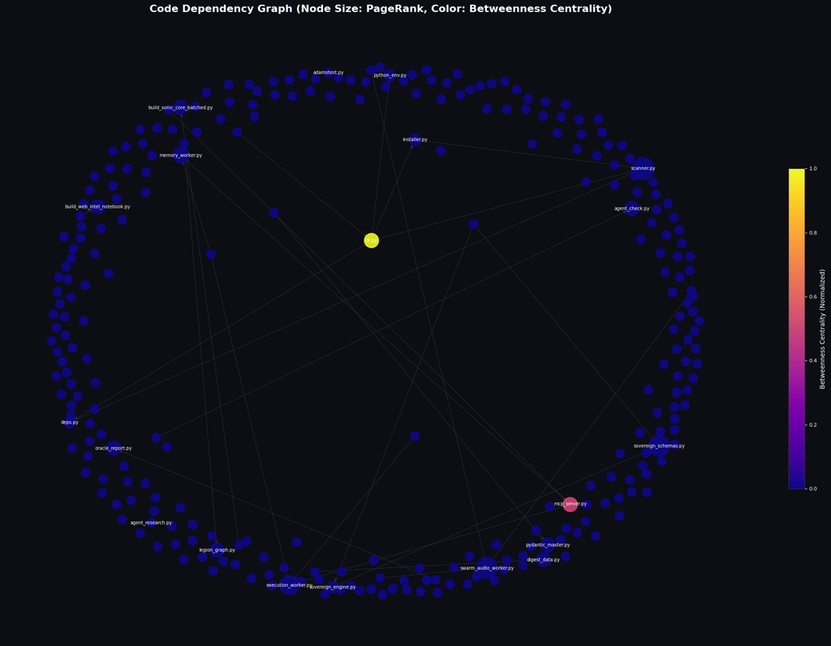

```
NetworkX visualization completed in 2.01 seconds.
```

```python
print("Generating NetworkX Dependency Graph visualization...")
t_start = time.perf_counter()

# --- 1. Build the graph ---
G = nx.DiGraph()
all_files = set(df_files['relative_path'].values)

for _, row in df_imports.iterrows():
    source_file = row['source']
    imported_module = row['imports']

    # For simplicity, map imported_module names to files if they are local
    # This requires converting module name 'foo' to 'foo.py' or finding the actual file
    target_file = None
    for f in all_files:
        if Path(f).stem == imported_module:
            target_file = f
            break

    if target_file and source_file in all_files and target_file in all_files:
        G.add_edge(source_file, target_file)
    elif source_file in all_files:
        G.add_node(source_file) # Ensure all source files are nodes even if they only import external modules

if not G.nodes():
    print("No internal dependency graph to visualize. Skipping.")
else:
    # Add isolated nodes (files with no internal imports/exports)
    for f in all_files:
        if f not in G:
            G.add_node(f)

    print(f"Graph built with {G.number_of_nodes()} nodes and {G.number_of_edges()} edges.")

    # --- 2. Calculate Centrality Measures ---
    pagerank = nx.pagerank(G, alpha=0.85) if G.number_of_nodes() > 0 else {}
    betweenness = nx.betweenness_centrality(G) if G.number_of_nodes() > 0 else {}

    # Normalize PageRank for node size
    if pagerank:
        max_pr = max(pagerank.values())
        min_pr = min(pagerank.values())
        node_sizes = [200 + (pagerank.get(node, 0) - min_pr) / (max_pr - min_pr + 1e-9) * 1000 for node in G.nodes()]
    else:
        node_sizes = [200] * G.number_of_nodes()

    # Normalize Betweenness for node color
    if betweenness:
        max_bc = max(betweenness.values())
        min_bc = min(betweenness.values())
        norm_bc = [(betweenness.get(node, 0) - min_bc) / (max_bc - min_bc + 1e-9) for node in G.nodes()]
    else:
        norm_bc = [0.0] * G.number_of_nodes()

    # --- 3. Visualization ---
    fig, ax = plt.subplots(1, 1, figsize=(18, 14))
    ax.set_facecolor('#0d0d14')

    pos = nx.spring_layout(G, k=0.8, iterations=50, seed=42) # Adjust k for desired node separation

    # Draw nodes with sizes based on PageRank and colors based on Betweenness Centrality
    cmap = plt.cm.plasma
    sm = plt.cm.ScalarMappable(cmap=cmap, norm=plt.Normalize(vmin=0, vmax=1))
    sm.set_array([])

    nx.draw_networkx_nodes(G, pos, node_size=node_sizes, node_color=norm_bc, cmap=cmap, alpha=0.9, ax=ax)
    nx.draw_networkx_edges(G, pos, edge_color='#444', alpha=0.4, arrows=True, arrowsize=10, ax=ax)

    # Draw labels only for top N nodes by PageRank
    labels = {node: Path(node).name for node in G.nodes()}
    sorted_pr_nodes = sorted(pagerank, key=pagerank.get, reverse=True)
    top_n_labels = {node: labels[node] for node in sorted_pr_nodes[:min(20, G.number_of_nodes())]}
    nx.draw_networkx_labels(G, pos, labels=top_n_labels, font_size=7, font_color='white', ax=ax)

    ax.set_title('Code Dependency Graph (Node Size: PageRank, Color: Betweenness Centrality)', color='white', fontsize=16, fontweight='bold')
    ax.axis('off')

    cbar = fig.colorbar(sm, ax=ax, orientation='vertical', fraction=0.02, pad=0.04)
    cbar.set_label('Betweenness Centrality (Normalized)', color='white', fontsize=10)
    cbar.ax.tick_params(colors='white')

    plt.tight_layout()
    plt.show()

t_end = time.perf_counter()
print(f"NetworkX visualization completed in {t_end - t_start:.2f} seconds.")
```

## 🌌 CELL 18 — Code Lane v2: UMAP Galaxy Map of Code Blocks

This plot visualizes your entire codebase as a 'galaxy' where each point represents a code block (function or class). Blocks are positioned based on their semantic similarity (derived from TF-IDF and UMAP reduction), and colored by their assigned K-Means cluster. Anomalous blocks (identified by IsolationForest) are highlighted in red, indicating potentially unique or unusual structural patterns.

```
Generating UMAP Galaxy Map visualization...
```

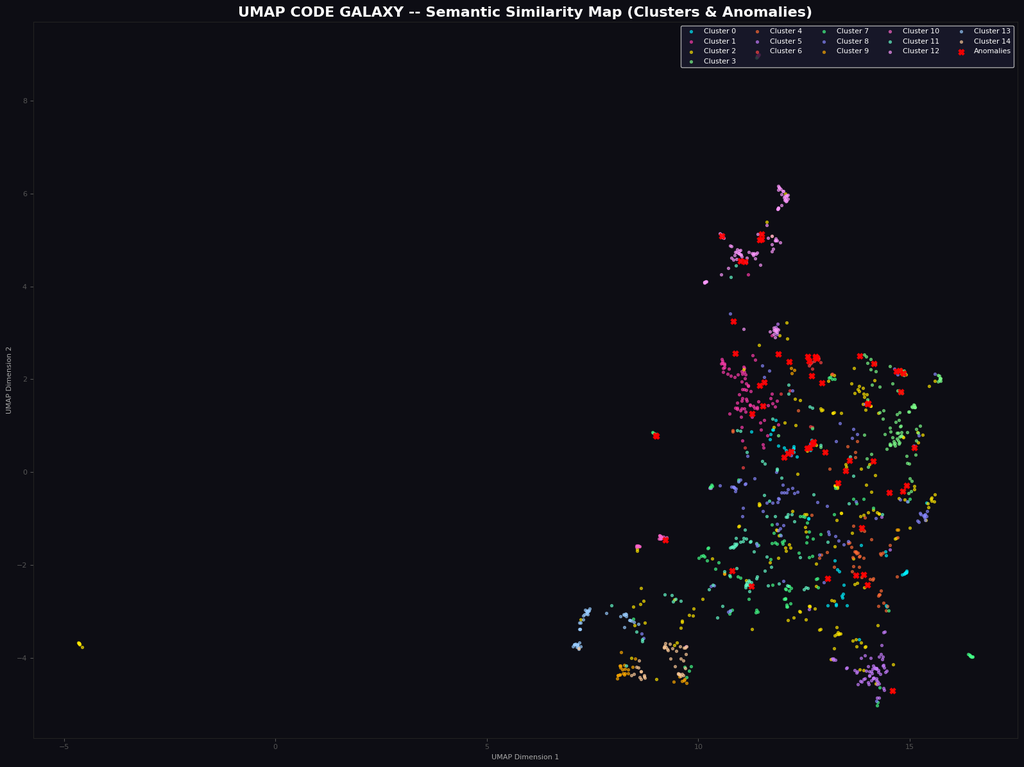

```
UMAP Galaxy Map visualization completed in 0.33 seconds.
```

```python
print("Generating UMAP Galaxy Map visualization...")
t_start = time.perf_counter()

if 'umap_x' not in df_blocks.columns or df_blocks['umap_x'].isnull().all():
    print("UMAP coordinates not available or insufficient data. Skipping UMAP Galaxy Map.")
elif auto_k == 0: # Check if clustering was performed (from Cell 16)
    print("Clustering was skipped due to insufficient data. UMAP visualization will not show clusters.")
    # Proceed with plotting without cluster colors if UMAP coords exist
    fig, ax = plt.subplots(1, 1, figsize=(16, 12))
    ax.set_facecolor('#0d0d14')
    ax.scatter(df_blocks['umap_x'], df_blocks['umap_y'],
               color='#00f0ff', alpha=0.6, s=8)
    outliers = df_blocks[df_blocks['code_outlier']]
    if not outliers.empty:
        ax.scatter(outliers['umap_x'], outliers['umap_y'],
                   color='red', alpha=0.9, s=40, marker='X', zorder=5, label='Anomalies')
        ax.legend(fontsize=8, labelcolor='white', facecolor='#1a1a2e', loc='upper right')
    ax.set_title('UMAP Code Galaxy -- Semantic Similarity Map (No Clusters)', color='white', fontsize=16, fontweight='bold')
    ax.tick_params(colors='#555')
    for s in ax.spines.values(): s.set_color('#222')
    plt.tight_layout()
    plt.show()

else:
    # Use a color palette (defined in the initial load cell for consistency)
    PALETTE = ['#00f0ff','#ff3cac','#ffe600','#7dff8a','#ff6b35','#c77dff',
               '#ff4444','#44ff88','#8888ff','#ffaa00','#ff66cc','#66ffcc',
               '#ff99ff','#99ccff','#ffcc99']

    fig, ax = plt.subplots(1, 1, figsize=(16, 12))
    ax.set_facecolor('#0d0d14')

    for i in range(auto_k):
        mask = df_blocks['cluster'] == i
        ax.scatter(df_blocks.loc[mask, 'umap_x'], df_blocks.loc[mask, 'umap_y'],
                   color=PALETTE[i % len(PALETTE)], alpha=0.6, s=8, label=f'Cluster {i}')

    outliers = df_blocks[df_blocks['code_outlier']]
    if not outliers.empty:
        ax.scatter(outliers['umap_x'], outliers['umap_y'],
                   color='red', alpha=0.9, s=40, marker='X', zorder=5, label='Anomalies')

    ax.legend(fontsize=8, ncol=min(5, auto_k), labelcolor='white', facecolor='#1a1a2e', loc='upper right')
    ax.set_title('UMAP CODE GALAXY -- Semantic Similarity Map (Clusters & Anomalies)', color='white', fontsize=16, fontweight='bold')
    ax.tick_params(colors='#555')
    for s in ax.spines.values(): s.set_color('#222')
    ax.set_xlabel('UMAP Dimension 1')
    ax.set_ylabel('UMAP Dimension 2')

    plt.tight_layout()
    plt.show()

t_end = time.perf_counter()
print(f"UMAP Galaxy Map visualization completed in {t_end - t_start:.2f} seconds.")
```

## 🌡️ CELL 19 — Code Lane v2: Radon Complexity & Maintainability Scatter

```
Generating Radon Complexity & Maintainability scatter plot...
```

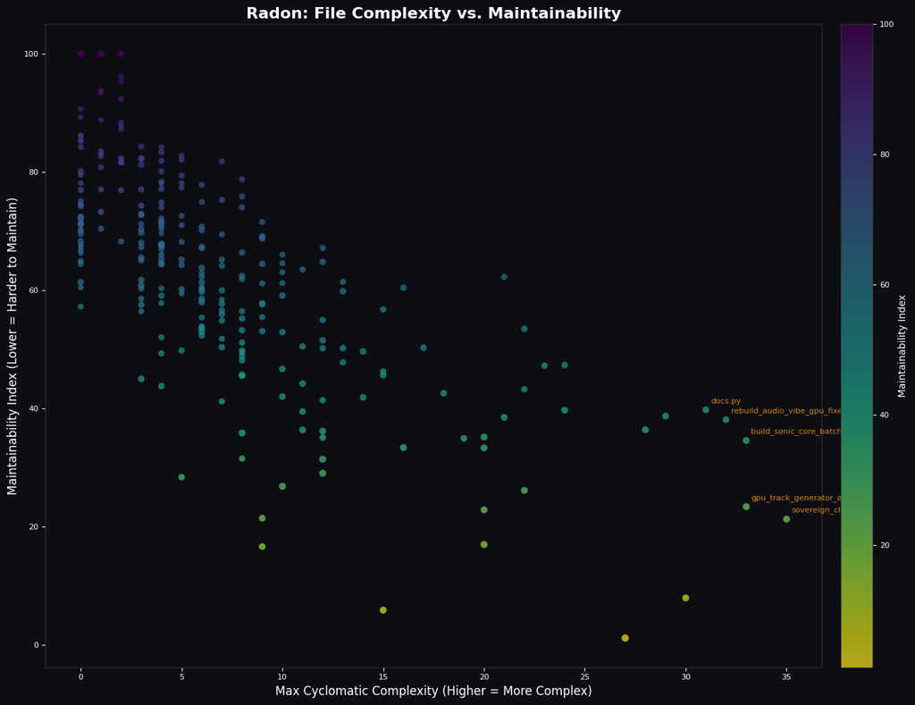

```
Radon complexity scatter plot visualization completed in 0.20 seconds.
```

```python
print("Generating Radon Complexity & Maintainability scatter plot...")
t_start = time.perf_counter()

if not HAS_RADON or 'max_cyclomatic' not in df_files.columns or df_files['max_cyclomatic'].isnull().all():
    print("Radon data not available or not calculated. Skipping Radon Complexity plot.")
else:
    fig, ax = plt.subplots(1, 1, figsize=(14, 10))
    ax.set_facecolor('#0d0d14')

    # Create a colormap for maintainability index (lower MI = red, higher MI = green/blue)
    cmap = plt.cm.viridis_r # _r reverses for lower MI = hotter color
    norm = mcolors.Normalize(vmin=df_files['maintainability_index'].min(), vmax=df_files['maintainability_index'].max())

    # Scale point size by character length, log scale for better distribution
    # Add a small constant to avoid log(0) if chars can be 0
    point_sizes = np.log1p(df_files['chars']) * 5 # Adjust multiplier for desired range
    point_sizes = point_sizes.replace([-np.inf, np.inf], 1).fillna(1)

    scatter = ax.scatter(df_files['max_cyclomatic'], df_files['maintainability_index'],
                         c=df_files['maintainability_index'], cmap=cmap, norm=norm,
                         s=point_sizes, alpha=0.7, edgecolors='none')

    ax.set_xlabel('Max Cyclomatic Complexity (Higher = More Complex)', color='white', fontsize=12)
    ax.set_ylabel('Maintainability Index (Lower = Harder to Maintain)', color='white', fontsize=12)
    ax.set_title('Radon: File Complexity vs. Maintainability', color='white', fontsize=16, fontweight='bold')
    ax.tick_params(colors='white')
    for s in ax.spines.values(): s.set_color('#333')

    cbar = fig.colorbar(scatter, ax=ax, orientation='vertical', pad=0.02)
    cbar.set_label('Maintainability Index', color='white', fontsize=10)
    cbar.ax.tick_params(colors='white')

    # Optional: Add labels for a few most complex/least maintainable files
    top_risk_files = df_files.nlargest(5, ['max_cyclomatic', 'maintainability_index'], keep='first')
    for _, row in top_risk_files.iterrows():
        ax.annotate(Path(row['filepath']).name,
                    (row['max_cyclomatic'], row['maintainability_index']),
                    textcoords="offset points", xytext=(5,5), ha='left', va='bottom',
                    color='orange', fontsize=8, alpha=0.8)

    plt.tight_layout()
    plt.show()

t_end = time.perf_counter()
print(f"Radon complexity scatter plot visualization completed in {t_end - t_start:.2f} seconds.")
```

## 🤖 CELL 20 — Code Lane v2: RandomForest Code Role Classifier & Feature Importances

This cell trains a RandomForest Classifier to predict the functional `code_role` of each block (e.g., 'test', 'engine', 'api') based purely on structural features (lines of code, branches, etc.). It then displays the importance of each structural feature in making these predictions, offering insights into what structural patterns define different code roles.

```
Training RandomForest Code Role Classifier and analyzing feature importances...
```

```
Classifier Accuracy: 0.47
```

```
Classification Report:
                precision    recall  f1-score   support

        agent       0.45      0.62      0.53         8
          api       0.20      0.23      0.21        13
        audit       0.19      0.25      0.21        12
    class_def       0.00      0.00      0.00         3
   deployment       0.25      0.67      0.36         3
       engine       0.42      0.45      0.43        22
    ingestion       0.40      0.37      0.38        38
 orchestrator       0.00      0.00      0.00         2
       schema       0.71      0.65      0.68        26
         test       0.56      0.78      0.65        23
      utility       0.60      0.44      0.51        72
visualization       0.33      1.00      0.50         1

     accuracy                           0.47       223
    macro avg       0.34      0.46      0.37       223
 weighted avg       0.49      0.47      0.47       223
```

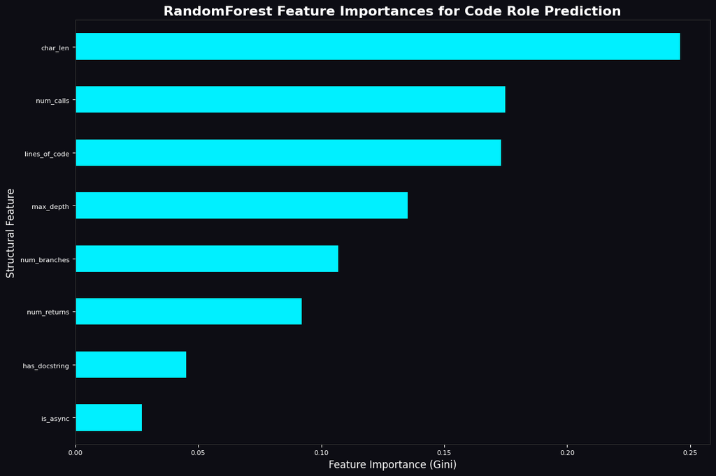

```
RandomForest classification and feature importance analysis completed in 0.34 seconds.
```

```python
print("Training RandomForest Code Role Classifier and analyzing feature importances...")
t_start = time.perf_counter()

# Prepare data for classification
X = df_blocks[STRUCT_FEATURES].fillna(0)
y = df_blocks['code_role']

if len(X) < 2 or y.nunique() < 2:
    print("Insufficient data or too few unique roles to train a classifier. Skipping RandomForest.")
else:
    # Split data into training and testing sets
    X_train, X_test, y_train, y_test = train_test_split(X, y, test_size=0.2, random_state=42, stratify=y)

    # Initialize and train RandomForestClassifier
    rf_classifier = RandomForestClassifier(n_estimators=100, random_state=42, class_weight='balanced')
    rf_classifier.fit(X_train, y_train)

    # Make predictions and evaluate
    y_pred = rf_classifier.predict(X_test)
    accuracy = accuracy_score(y_test, y_pred)
    print(f"\nClassifier Accuracy: {accuracy:.2f}")
    print("\nClassification Report:\n", classification_report(y_test, y_pred, zero_division=0))

    # --- Feature Importances Visualization ---
    feature_importances = pd.Series(rf_classifier.feature_importances_, index=STRUCT_FEATURES).sort_values(ascending=False)

    fig, ax = plt.subplots(1, 1, figsize=(12, 8))
    ax.set_facecolor('#0d0d14')

    feature_importances.plot.barh(ax=ax, color='#00f0ff')
    ax.set_title('RandomForest Feature Importances for Code Role Prediction', color='white', fontsize=16, fontweight='bold')
    ax.set_xlabel('Feature Importance (Gini)', color='white', fontsize=12)
    ax.set_ylabel('Structural Feature', color='white', fontsize=12)
    ax.tick_params(colors='white')
    for s in ax.spines.values(): s.set_color('#333')
    plt.gca().invert_yaxis() # Highest importance at the top

    plt.tight_layout()
    plt.show()

t_end = time.perf_counter()
print(f"RandomForest classification and feature importance analysis completed in {t_end - t_start:.2f} seconds.")
```

## 🌳 CELL 21 — Code Lane v2: Hierarchical Cluster Dendrogram

This dendrogram illustrates the hierarchical relationships between the semantic clusters identified in your codebase. It shows how smaller, more specific clusters merge into broader categories, revealing the underlying architectural structure and thematic organization of your code at different levels of granularity.

```
Generating Hierarchical Cluster Dendrogram...
```

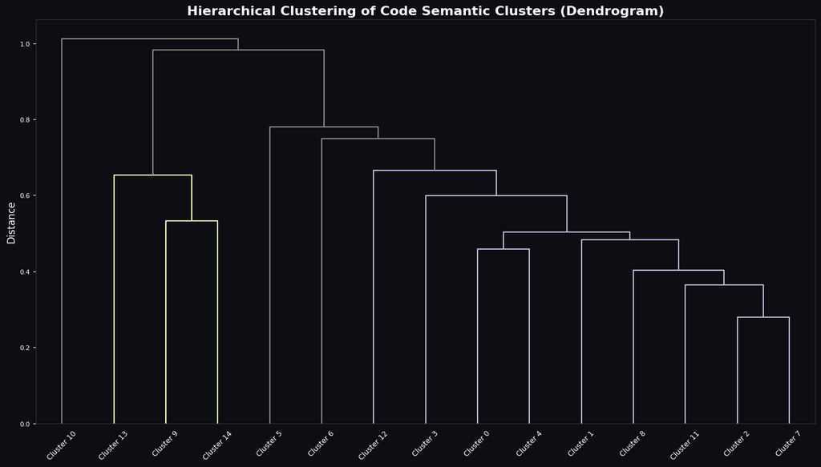

```
Dendrogram visualization completed in 0.15 seconds.
```

```python
print("Generating Hierarchical Cluster Dendrogram...")
t_start = time.perf_counter()

if 'cluster' not in df_blocks.columns or auto_k < 2:
    print("Clustering data not available or fewer than 2 clusters. Skipping Dendrogram.")
else:
    # Ensure kmeans_model is available from CELL 16
    if 'kmeans_model' not in locals():
        print("KMeans model not found. Please run CELL 16 first.")
    else:
        cluster_centers = kmeans_model.cluster_centers_

        # Calculate the linkage matrix
        # Use 'euclidean' distance and 'ward' method for hierarchical clustering
        Z = linkage(pdist(cluster_centers, 'euclidean'), method='ward')

        fig, ax = plt.subplots(1, 1, figsize=(14, 8))
        ax.set_facecolor('#0d0d14')

        dendrogram(Z, ax=ax, labels=[f'Cluster {i}' for i in range(auto_k)],
                   leaf_font_size=9, color_threshold=0.7 * max(Z[:, 2]),
                   above_threshold_color='#888', orientation='top')

        ax.set_title('Hierarchical Clustering of Code Semantic Clusters (Dendrogram)', color='white', fontsize=16, fontweight='bold')
        ax.set_ylabel('Distance', color='white', fontsize=12)
        ax.tick_params(colors='white')
        for s in ax.spines.values(): s.set_color('#333')
        ax.tick_params(axis='x', rotation=45)

        plt.tight_layout()
        plt.show()

t_end = time.perf_counter()
print(f"Dendrogram visualization completed in {t_end - t_start:.2f} seconds.")
```

## ❓ CELL 22 — Code Lane v2: Ask a Question (TF-IDF Similarity Search)

Enter a keyword or phrase, and this cell will identify the most semantically similar code blocks from your codebase using TF-IDF. This acts as a powerful knowledge retrieval mechanism, helping you quickly find relevant functions, classes, or code snippets related to a specific concept or task.

```python
print("Ready to perform TF-IDF similarity search. Enter your query below.")

# Ensure TF-IDF vectorizer and matrix are available from CELL 16
if 'tfidf_vectorizer' not in locals() or 'tfidf_matrix' not in locals():
    print("TF-IDF models not found. Please run CELL 16 first.")
elif df_blocks.empty:
    print("No code blocks to search. Skipping similarity search.")
else:
    def find_similar_code_blocks(query_keyword, top_n=5):
        t_start_query = time.perf_counter()
        # Vectorize the query
        query_vec = tfidf_vectorizer.transform([query_keyword.lower()])

        # Calculate cosine similarity
        # (tfidf_matrix * query_vec.T).toarray() for scipy sparse matrix
        similarities = (tfidf_matrix * query_vec.T).toarray().flatten()

        # Get top N most similar blocks
        top_indices = similarities.argsort()[-top_n:][::-1]

        print(f"\n--- Top {top_n} Code Blocks for '{query_keyword}': ---")
        results = []
        for idx in top_indices:
            score = similarities[idx]
            if score > 0:
                block = df_blocks.iloc[idx]
                results.append({
                    'Similarity Score': f"{score:.4f}",
                    'Symbol Name': block['symbol_name'],
                    'Type': block['type'],
                    'Source File': block['relative_path'],
                    'Docstring Snippet': block['docstring'][:100].replace('\n', ' ') + '...' if block['docstring'] else '',
                    'Code Preview': block['code_content'][:200].replace('\n', ' ') + '...'
                })

        if not results:
            print("No relevant code blocks found.")
        else:
            for r in results:
                print(f"  Score: {r['Similarity Score']} | Name: {r['Symbol Name']} ({r['Type']})")
                print(f"    File: {r['Source File']}")
                print(f"    Doc: {r['Docstring Snippet']}")
                # print(f"    Code: {r['Code Preview']}") # Uncomment for code preview
                print()
        t_end_query = time.perf_counter()
        print(f"Query completed in {t_end_query - t_start_query:.4f} seconds.")
        return results

    # --- Example Usage ---
    query = "agent orchestration"
    find_similar_code_blocks(query)

    query = "database operations"
    find_similar_code_blocks(query)

    query = "test setup"
    find_similar_code_blocks(query, top_n=3)

    # You can also uncomment the line below to ask for interactive input:
    # interactive_query = input("\nEnter a keyword to search your code: ")
    # if interactive_query:
    #     find_similar_code_blocks(interactive_query)
```

```
Ready to perform TF-IDF similarity search. Enter your query below.

--- Top 5 Code Blocks for 'agent orchestration': ---
  Score: 0.4425 | Name: test_agent (function)
    File: test_pydantic_agent.py
    Doc:

  Score: 0.4409 | Name: main (function)
    File: test_adk.py
    Doc:

  Score: 0.4038 | Name: run_test (function)
    File: test_tydantics.py
    Doc:

  Score: 0.3572 | Name: Skill (class)
    File: library-skills/src/library_skills/scanner.py
    Doc: A discovered agent skill....

  Score: 0.2916 | Name: relay_tuning_instructions (function)
    File: test_pydantic_agent.py
    Doc:

Query completed in 0.0049 seconds.

--- Top 5 Code Blocks for 'database operations': ---
  Score: 0.3418 | Name: check_ingestion_status (function)
    File: mcp_server.py
    Doc: Checks the real-time background ingestion status of the sonic_core_v2 DuckDB database. Returns the t...

  Score: 0.2736 | Name: lookup_reference_filename (function)
    File: AI_Logs/gpu_track_generator_async.py
    Doc: Looks up reference track filepath in DuckDB database....

  Score: 0.2294 | Name: get_track_dna (function)
    File: mcp_server.py
    Doc: Retrieves the full technical DNA (BPM, Key, Spectral features) of a specific track  from the sonic_c...

  Score: 0.1780 | Name: AlignedDSPTrackRecord (class)
    File: sovereign_schemas.py
    Doc: Pre-inference validated track record — raw database output must pass through this before any LLM see...

  Score: 0.1747 | Name: search_tracks (function)
    File: mcp_server.py
    Doc: Searches the DuckDB database of 9,000+ audio tracks by BPM, Key, Artist, or Title. Returns matching ...

Query completed in 0.0017 seconds.

--- Top 3 Code Blocks for 'test setup': ---
  Score: 0.3154 | Name: test_system (function)
    File: legion_sdk_test.py
    Doc:

  Score: 0.3109 | Name: test_model_load (function)
    File: test_cortex.py
    Doc: Test 1: Load model with explicit GPU mapping....

  Score: 0.3092 | Name: main (function)
    File: swarm_audio_worker.py
    Doc:

Query completed in 0.0011 seconds.
```